# The hydraulic P-model

Jaideep Joshi

2021-09-26

```r
par_plant_std = list(
  # Ks0=1e-12,              # m2
  # v_huber=1e-4,           #
  # height=10,              # m
  # conductivity_scalar=3,  # Scales (Ks0*v_huber/H)
  conductivity = 3e-17,
  psi50 = -2,             # Mpa
  b=2                    #
)

tc=25
p = rpmodel::calc_patm(0)
vpd = 1000

par_env_std = list(
  viscosity_water = rpmodel::calc_viscosity_h2o(tc, p),  # Needs to be imported from rpmodel.R
  density_water = rpmodel::calc_density_h2o(tc, p),  # Needs to be imported from rpmodel.R
  patm = p,
  tc = tc,
  vpd = vpd
)
```

## Hydraulics

The key aspect of the flow of liquid water through the plant’s hydraulic pathways is that the conductivity of these pathways declines as water potential becomes more and more negative. This loss of conductivity is described by a vulnerability curve of the form:

$$P(\psi)=\left(\frac{1}{2}\right)^{\left(\frac{\psi}{\psi_{50}}\right)^b}$$

### Hydraulic vulnerability curve

```r
P <- function(psi, psi50, b){
  0.5^((psi/psi50)^b)
}

Pprime = function(psi, psi50, b){
  log(0.5)*P(psi, psi50, b)*b*(psi/psi50)^(b-1)/psi50
}

Pprimeprime = function(psi, psi50, b){
  log(0.5)*b*(psi/psi50)^(b-1)/psi50*Pprime(psi, psi50, b) + log(0.5)*P(psi, psi50, b)/psi50^2*b*(b-1)*(psi/psi50)^(b-2)
}
```

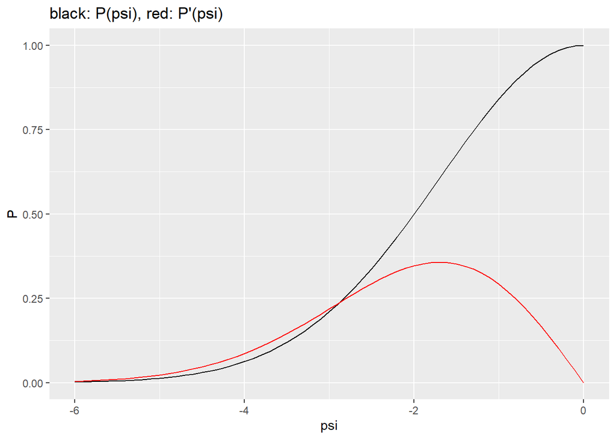

```r
tibble(psi=seq(-6,0, 0.1)) %>%
mutate(P = purrr::map_dbl(psi, ~P(., par_plant_std$psi50, par_plant_std$b))) %>%
mutate(Pprime = purrr::map_dbl(psi, ~Pprime(., par_plant_std$psi50, par_plant_std$b))) %>%
mutate(Pprimeprime = purrr::map_dbl(psi, ~Pprimeprime(., par_plant_std$psi50, par_plant_std$b))) %>%
ggplot()+
geom_line(aes(x=psi, y=P))+
geom_line(aes(x=psi, y=Pprime), color="red")+
ggtitle("black: P(psi), red: P'(psi)")
```

### Water flow in the stem and in the leaf

#### Water flow through a general conducting pathway

In general, water flux through any conductive pathway in the plant follows the following differential equation:

$$\frac{d\psi}{dh} = -\rho g - \frac{\eta Q}{K(h)P(\psi,h)}$$
where $\psi$ is the water potential at a distance $h$ from the starting point, $Q$ is the flux of water through the pathway, $\eta$ is the viscosity of water, $g$ is the component of gravity in the direction of the flow, $K$ is the conductivity of the pathway. $K$ and $P$ may depend on $h$ due to structural variations, such as variation in the vessel geometry with height (vessel tapering).

#### Flow through the stem in xylem

Water is conducted through the stem by interconnected xylem vessels. The conductivity of a single vessel with length $l_v$ and radius $r_v$ is given by the Hagen-Poiseuille equation:
$$K_v = \frac{\pi r_v^4}{8l_v}$$

If the sapwood has has a density $\rho_v$ of vessels, their conductance will add up (as the vessels are in parallel). The conductivity of a section of sapwood of unit length per unit unit area (sapwood specific conductivity) would then be

$$K_s = \frac{\pi\rho_v r_v^4}{8}$$

For typical vessel characteristics (Choat et al. 2005): $\rho_v = 217 \mathrm{/mm^2}, r_v = 15.25\ \mathrm{\mu m}$, which gives a theoretical conductivity to be $K_s = \pi\rho_v r_v^4 / 8 = 4.6\times 10^{-12}\ \mathrm{m^2}$. The actual conductivity is about 4x lower: $K_{s,\text{actual}} = 1.15\times 10^{-12} = 1.29\ \mathrm{kg\cdot m^{-1} \cdot s^{-1} \cdot Mpa^{-1}}$.

If we ignore gravitational and xylem tapering effects, we can use the above equation for the stem to express $Q$ as:
$$Q = -\frac{K_{s} \nu_H}{H \eta} \int_{\psi_s}^{\psi_p} P_s(\psi) d\psi,$$
where the subscripts $s$ and $p$ represent the soil and end of the petiole respectively, and $P_s(\psi)$ represents the vulnerability curve for the stem. Stem vulnerability is largely due to xylem cavitation. Since $Q$ is expressed as the flux of water per unit leaf area, we multiply the sapwood specific conductivity by the Huber Value ($\nu_H$) to get the leaf specific conductivity.

#### Flow through outside xylem pathways

Once the water exits the xylem near the petiole, it must pass through bundle sheath cells and several layers of spongy mesophyll cells before reaching the stomata, from where it vapourizes from the cell walls and out into the atmosphere. These outside-xylem pathways offer much larger resistence to water flow compared to xylem, and lose conductivity much faster than xylem, making the leaf the hydraulic bottleneck in the flow of water.

We can represent the sum total flow through all the different outside-xylem pathways (through the cell walls and cell mesophyll) in the same way as the flow through the stem,

$$Q = -\frac{K_{l}}{\Delta L \eta} \int_{\psi_p}^{\psi_l} P(\psi) d\psi,$$
where $K_l$ is the conductivity of the leaf per unit leaf area, $\Delta L$ is the path length that water must traverse outside the xylem, and the subscript $l$ represents the leaf (more accurately, the endpoint of the hydraulic pathway, near the stomatal cells). The path length $\Delta L$ depends on the leaf thickness (LMA) and the vein length per unit leaf area (VLA).

### Water Balance

Ignoring storage and capacitance effects, this flow $Q$ must equal transpiration through leaves $E=1.6g_s D$ to satisfy water balance:

$$Q = -\frac{K_{s} \nu_H}{H \eta} \int_{\psi_s}^{\psi_p} P_s(\psi) d\psi = -\frac{K_{l}}{\Delta L \eta} \int_{\psi_p}^{\psi_l} P(\psi) d\psi = 1.6g_sD$$

For simplicity, let us we club the net conductivity of the stem and leaf into single variables, and express the water potential difference from petiole to leaf as $\Delta \psi$:

$$Q = -\frac{K_{S}}{\eta}\int_{\psi_s}^{\psi_p = \psi_s -\Delta\psi_s} P_s(\psi) d\psi = -\frac{K_{L}}{\eta} \int_{\psi_p}^{\psi_p-\Delta \psi} P(\psi) d\psi = 1.6g_sD$$

Given $\Delta\psi$, this gives us two nonlinear simultaneous equations which can be solved iteratively for $g_s$ and $\psi_p$. However, if we make a simplifying assumption as described below, we can solve for $g_s$ analytically.

### Leaf as the hydraulic bottleneck

There is increasing evidence that the leaf is the hydraulic bottleneck in the flow of water through the plant. This manifests in two ways: 1) The xylem conductivity is much larger than the leaf conductivity ($K_{S} \gg K_L$). Thus, the drop in water potential along the xylem pathway is much lesser compared to that in the outside-xylem pathway ($\Delta\psi_s \ll \Delta\psi$), and 2) the operating water potential (water potential until stomatal closure) in the xylem is much lower (less negative) than required to cause embolism. Therefore $P_s(\psi) \approx 1$. With these assumptions, $\Delta\psi_s \approx 0$, and $\psi_p \approx \psi_s$.

### Stomatal conductance

With the above simplifications, we can express $g_s$ in terms of $\Delta \psi$ as

$$g_s = -\frac{K_L}{1.6D\eta}\int_{\psi_s}^{\psi_s-\Delta\psi}P(\psi)d\psi$$

We further note that due to the water balance condition, $g_s$ is independent of $\chi$.

```r
calc_conductivity_m = function(sapwood_perm, hv, height){
  sapwood_perm*hv/height
}

## Returns conductivity in mol/m2/s/Mpa
scale_conductivity = function(K, par_env){
  # Flow rate in m3/m2/s/Pa
  K2 = K / par_env$viscosity_water

  # Flow rate in mol/m2/s/Pa
  mol_h20_per_kg_h20 = 55.5
  K3 = K2 * par_env$density_water * mol_h20_per_kg_h20

  # Flow rate in mol/m2/s/Mpa
  K4 = K3*1e6

  return(K4)
}


## Integral of the vulnerabiity curve
## integral of P(psi)dpsi  (Mpa)
integral_P_ana = function(dpsi, psi_soil, psi50, b, ...){
  ps = psi_soil/psi50
  pl = (psi_soil-dpsi)/psi50
  l2 = log(2)
  -(psi50/b)*(l2^(-1/b))*(expint::gammainc(a = 1/b, x = l2*pl^b)-expint::gammainc(a = 1/b, x = l2*ps^b))
}

integral_P_num = function(dpsi, psi_soil, psi50, b, ...){
  integrate(P, psi50=psi50, b=b, lower = psi_soil, upper = (psi_soil - dpsi), ...)$value
  # -(P(psi_soil, psi50=psi50, b=b)*dpsi) # Linearized version
}

integral_P_approx = function(dpsi, psi_soil, psi50, b, ...){
  -dpsi * P(psi_soil-dpsi/2, psi50, b)
}


calc_gs = function(dpsi, psi_soil, par_plant, par_env, ...){
  K = scale_conductivity(par_plant$conductivity, par_env)
  D = (par_env$vpd/par_env$patm)
  K/1.6/D * -integral_P(dpsi, psi_soil, par_plant$psi50, par_plant$b, ...)
  # # papprox = P(psi_soil-dpsi/2, par_plant$psi50, par_plant$b)
  # papprox = P(psi_soil, par_plant$psi50, par_plant$b)-Pprime(psi_soil, par_plant$psi50, par_plant$b)*dpsi/2.5
  # K/1.6/D * dpsi * papprox

}

## Derivative of gs wrt dpsi (mol/m2/s/Mpa)
calc_gsprime_analytical = function(dpsi, psi_soil, par_plant, par_env){
  K = scale_conductivity(par_plant$conductivity, par_env)
  D = (par_env$vpd/par_env$patm)
  K/1.6/D*P(psi_soil-dpsi, par_plant$psi50, par_plant$b)
}

## Derivative of gs wrt dpsi (mol/m2/s/Mpa)
calc_gsprime_approx = function(dpsi, psi_soil, par_plant, par_env){
  K = scale_conductivity(par_plant$conductivity, par_env)
  D = (par_env$vpd/par_env$patm)
  K/1.6/D*(P(psi_soil-dpsi/2, par_plant$psi50, par_plant$b) - Pprime(psi_soil-dpsi/2, par_plant$psi50, par_plant$b)*dpsi/2)
}


# ~~ For verification only ~~
# Numerical derivative of gs wrt dpsi (mol/m2/s/Mpa)
calc_gsprime_numerical = function(dpsi, psi_soil, par_plant, par_env, ...){
  (calc_gs(dpsi+.01, psi_soil, par_plant, par_env, ...)-calc_gs(dpsi, psi_soil, par_plant, par_env, ...))/.01
}


calc_gsprime = calc_gsprime_analytical
integral_P = integral_P_ana
```

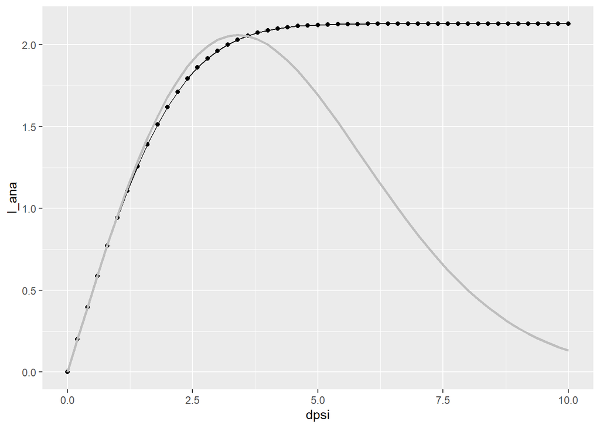

```r
## compare numerical and analytical versions of integral_P
tibble(dpsi=seq(0, 10, 0.2)) %>%
  mutate(I_ana = -purrr::map_dbl(dpsi, ~integral_P_ana(., 0, -2,2))) %>%
  mutate(I_num = -purrr::map_dbl(dpsi, ~integral_P_num(., 0, -2,2))) %>%
  mutate(I_approx = -purrr::map_dbl(dpsi, ~integral_P_approx(., 0, -2,2))) %>%
  ggplot()+
  geom_line(aes(x=dpsi, y=I_ana))+
  geom_point(aes(x=dpsi, y=I_num))+
  geom_line(aes(x=dpsi, y=I_approx), color="grey", size=1)
```

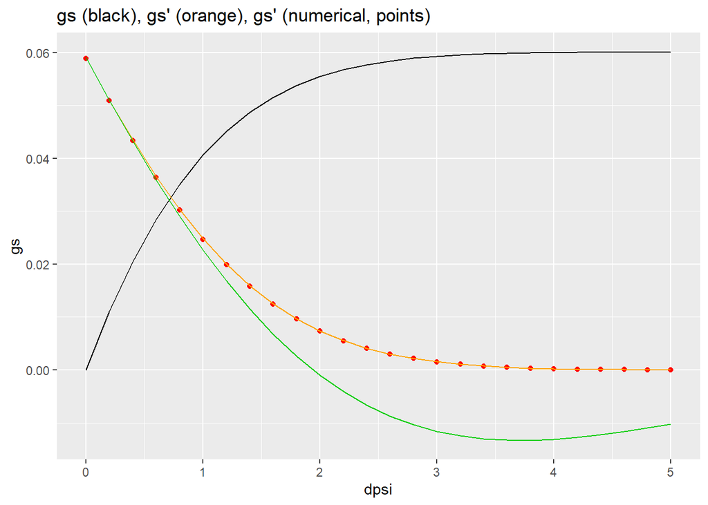

```r
ps = -2
## Plot gs and its derivatives
tibble(dpsi=seq(0, 5, 0.2)) %>%
  mutate(gs = purrr::map_dbl(dpsi, ~calc_gs(., ps, par_plant_std, par_env_std))) %>%
  mutate(gsprime_num = purrr::map_dbl(dpsi, ~calc_gsprime_numerical(., ps, par_plant_std, par_env_std))) %>%   mutate(gsprime = purrr::map_dbl(dpsi, ~calc_gsprime(., ps, par_plant_std, par_env_std))) %>%
  mutate(gsprime_approx = purrr::map_dbl(dpsi, ~calc_gsprime_approx(., ps, par_plant_std, par_env_std))) %>%
  ggplot()+
  geom_line(aes(x=dpsi, y=gs))+
  geom_point(aes(x=dpsi, y=gsprime_num), color="red")+
  geom_line(aes(x=dpsi, y=gsprime), color="orange")+
  geom_line(aes(x=dpsi, y=gsprime_approx), color="green3")+
  ggtitle("gs (black), gs' (orange), gs' (numerical, points) ")
```

## Photosynthesis

### Rates of carbon fixation

The rate of photosynthesis is the minimum of the electron transport limited and the carbxylation limited rates.

The carboxylation-limited rate is given by the Cowan-Farquhar biochemical model:

$$A_c = V_\mathrm{cmax}\frac{c_i - \Gamma^*}{c_i + K} - R_d$$
where $R_d$ is dark respiration, which is assumed to be proportional to $V_\mathrm{cmax}$.

$$R_d = \delta V_\mathrm{cmax}$$

Therefore, $A_c$ can be written as

$$A_c = V_\mathrm{cmax}\frac{c_i(1-\delta) - (\Gamma^*+\delta K)}{c_i + K}$$

The electron transport limited rate is given by

$$A_j = A_{Jm}\frac{c_i - \Gamma^*}{c_i + 2\Gamma^*} - R_d$$

where

$$A_{Jm} = \frac{\phi_0 I_\mathrm{abs}}{\sqrt{1+\left( \frac{4\phi_0 I_\mathrm{abs}}{J_\mathrm{max}}\right)^2}}$$

Inverting the above relation, we can express $J_\mathrm{max}$ in terms of $A_{Jm}$ as

$$J_\mathrm{max} = \frac{4\phi_0 I_\mathrm{abs}}{\sqrt{\left( \frac{\phi_0 I_\mathrm{abs}}{A_{Jm}}\right)^2-1}}$$

The rate of CO2 fixation must also equal the rate of CO2 uptake by the plant:
$$A = g_s c_a (1-\chi)$$

### Coordination hypothesis

The coordination hypothesis states that $V_\mathrm{cmax}$ should be large enough to fully utilize the available electron transport capacity, but not in excess of it, so as to save on costs of maintaining the carboxylation capacity.

We assume that Vcmax adjusts to the prevailing daytime light and moisture conditions (i.e, to available $J_\mathrm{max}$) such that the carboxylation-limited and electron-transport-limited assimilation rates are equal.

$$A = A_c = A_j$$

Therefore
$$V_\mathrm{cmax}\frac{c_i - \Gamma^*}{c_i + K} -R_d = A_{Jm}\frac{c_i - \Gamma^*}{c_i + 2\Gamma^*} - R_d$$

Therefore,
$$V_\mathrm{cmax} = A_{Jm}\frac{c_i +K}{c_i + 2\Gamma^*}$$

Therefore, $A_j$ can be rewritten as

$$A_j = g_s c_a (1-\chi) = A_{Jm}\frac{c_i(1-\delta) - (\Gamma^*+\delta K)}{c_i + 2\Gamma^*}$$

Therefore, $A_{Jm}$ can be expressed in terms of $\chi$ as

$$A_{Jm} = g_s c_a \frac{(1-\chi)(\chi c_a + 2\Gamma^*)}{\chi c_a(1-\delta) - (\Gamma^*+\delta K) }$$

This gives us an expression for $J_\mathrm{max}$ in terms of $g_s$ and $\chi$.

### Calculate the limiting rate from $g_s$ and Jmax / Vcmax

It is useful to be able to calculate the limiting rate and the resultant $c_i$ when $g_s$, $J_\mathrm{max}$ and the coordinated $V_\mathrm{cmax}$ are known. This can be used for daily or sub-daily photosynthesis rates when the photosynthetic capacity does not change, but other environmental variables such as light intensity change.

#### Rubisco limited assimilation rate

This can be found by solving:
$$A = g_s (c_a- c_i) = \mathrm{V_\mathrm{cmax}} \frac{c_i(1-\delta) - (\Gamma^*+\delta K)}{c_i + K}$$
so that
$$g_s(c_a-c_i)(c_i+K) = \mathrm{V_\mathrm{cmax}} (c_i(1-\delta) - (\Gamma^*+\delta K))$$
$$g_s c_a c_i + g_s c_a K - g_s c_i^2 -g_s c_i K = \mathrm{V_\mathrm{cmax}} c_i(1-\delta) - \mathrm{V_\mathrm{cmax}} (\Gamma^*+\delta K)$$
$$-g_sc_i^2 + (g_s c_a - g_s K -\mathrm{V_\mathrm{cmax}}(1-\delta)) c_i + (g_s c_a K + \mathrm{V_\mathrm{cmax}} (\Gamma^*+\delta K)) = 0$$

#### Light Limited assimilation rate

This can be found by solving:
$$A = g_s (c_a- c_i) = A_{Jm} \frac{c_i(1-\delta) - (\Gamma^*+\delta K)}{c_i + 2\Gamma^*}$$
which is identical to the above system, but with $V_\mathrm{cmax}$ replaced by $A_{Jm}$ and $K$ replaced by $2\Gamma^*$ in the denominator. It therefore leads to the equation:

$$-g_sc_i^2 + (g_s c_a - 2g_s \Gamma^* -A_{Jm}(1-\delta)) c_i + (2g_s c_a \Gamma^* + A_{Jm} (\Gamma^*+\delta K)) = 0$$

Here are the rates with with and without $J_\mathrm{max}$ limitation:

```r
#### Photosynthesis Rates ####

# Calculate Assimilation rate (umol/m2/s), given
# - gs (mol/m2/s)
# - vcmax (umol/m2/s)
# - Photosynthesis parameters with concentrations converted to partial pressures (Pa)
calc_assim_rubisco_limited <- function(gs, vcmax, par_photosynth){

  ca = par_photosynth$ca             # ca is in Pa
  gs = gs * 1e6/par_photosynth$patm  # convert to umol/m2/s/Pa

  d = par_photosynth$delta
  ## with
  A <- -1.0 * gs
  B <- gs * ca - gs * par_photosynth$kmm - vcmax*(1-d)
  C <- gs * ca * par_photosynth$kmm + vcmax * (par_photosynth$gammastar + par_photosynth$kmm*d)

  ci <- QUADM(A, B, C)
  # a_c <- vcmax * (ci - par$gammastar) / (ci + par$kmm)
  a_c <- gs*(ca-ci)

  return(list(a=a_c, ci=ci))
}

# Calculate Assimilation rate (umol/m2/s), given
# - gs (mol/m2/s)
# - jmax (umol/m2/s)
# - Photosynthesis parameters with concentrations converted to partial pressures (Pa)
# - Iabs (umol/m2/s)
calc_assim_light_limited <- function(gs, jmax, par_photosynth){

  ## Only light is limiting
  ## Solve Eq. system
  ## A = gs (ca- ci)
  ## A = phi0 * Iabs * jlim * (ci - gammastar)/(ci + 2*gamma_star)

  ## This leads to a quadratic equation:
  ## A * ci^2 + B * ci + C  = 0
  ## 0 = a + b*x + c*x^2

  ca = par_photosynth$ca             # ca is in Pa
  gs = gs * 1e6/par_photosynth$patm  # convert to umol/m2/s/Pa

  phi0iabs = par_photosynth$phi0 * par_photosynth$Iabs
  jlim = phi0iabs / sqrt(1+ (4*phi0iabs/jmax)^2)

  d = par_photosynth$delta
  ## with
  A <- -1.0 * gs
  B <- gs * ca - gs * 2 * par_photosynth$gammastar - jlim*(1-d)
  C <- gs * ca * 2*par_photosynth$gammastar + jlim * (par_photosynth$gammastar + d*par_photosynth$kmm)

  ci <- QUADM(A, B, C)
  aj <- gs*(ca-ci)
  # vcmax_pot <- a*(ci + par$kmm)/(ci - par$gammastar)

  return(list(a=aj, ci=ci))
}

calc_assimilation_limiting = function(vcmax, jmax, gs, par_photosynth){
  # gs = calc_gs(dpsi, psi_soil, par_plant = par_plant, par_env = par_env)

  # We need not employ numerical root-finding. calculate chi independently assuming Ac and Aj, and bigger of the two will be the limiting one. Accordingly return Ac or Aj
  Ac = calc_assim_rubisco_limited(gs = gs, vcmax = vcmax, par_photosynth = par_photosynth)
  Aj = calc_assim_light_limited(gs = gs, jmax = jmax, par_photosynth = par_photosynth)

  A = list(ac = Ac$a, aj=Aj$a)

  if (Ac$ci > Aj$ci ){
    A$ci = Ac$ci
    A$a  = Ac$a
  } else {
    A$ci = Aj$ci
    A$a  = Aj$a
  }

  A
}
```

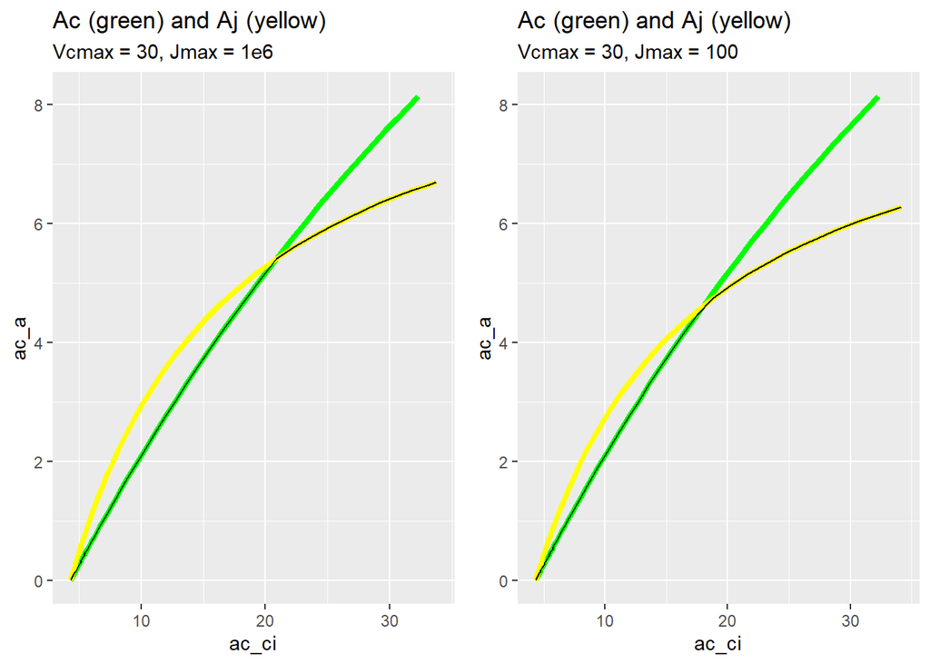

```r
get_std_photosythnesis_params = function(){
  ## Set P-model parameters
  kphio <- 0.05        # quantum yield efficiency
  # c_molmass <- 12.0107 # molar mass, g / mol

  ## Define environmental conditions
  tc <- 25             # temperature, deg C
  ppfd <- 400          # umol/m2/s
  # vpd  <- 1000         # Pa
  co2  <- 400          # ppm
  elv  <- 0            # m.a.s.l.
  fapar <- 0.7         # fraction

  p = rpmodel::calc_patm(elv)
  return (list(
    kmm = rpmodel::calc_kmm(tc, p),  # Why does this use std. atm pressure, and not p(z)?
    gammastar = rpmodel::calc_gammastar(tc, p),
    phi0 = kphio*rpmodel::calc_ftemp_kphio(tc),
    Iabs = ppfd*fapar,
    ca = co2*p*1e-6,  # Convert to partial pressure
    patm = p,
    delta = 0.00
  ))
}

df_ac_aj <- tibble(gs = exp(seq(log(0.000001), log(.1), length.out=100))) %>%
  mutate(aj = purrr::map(gs, ~calc_assim_light_limited(gs = ., jmax = 1e6, par_photosynth = get_std_photosythnesis_params()))) %>%
  unnest_wider(aj, names_sep = "_") %>%
  mutate(ac = purrr::map(gs, ~calc_assim_rubisco_limited(vcmax = 30, gs = ., par_photosynth = get_std_photosythnesis_params()))) %>%
  unnest_wider(ac, names_sep = "_") %>%
  mutate(a = purrr::map(gs, ~calc_assimilation_limiting(vcmax=30, jmax=1e6, gs = ., par_photosynth = get_std_photosythnesis_params()))) %>%
  unnest_wider(a, names_sep = "_")

p1 = df_ac_aj %>%
  ggplot()+
  geom_line(aes(x=ac_ci, y=ac_a), col="green", size=1.5) +
  geom_line(aes(x=aj_ci, y=aj_a), col="yellow", size=1.5) +
  geom_line(aes(x=a_ci, y=a_a), col="black")+
  labs(title = "Ac (green) and Aj (yellow)", subtitle = "Vcmax = 30, Jmax = 1e6")


df_ac_aj <- tibble(gs = exp(seq(log(0.000001), log(.1), length.out=100))) %>%
  mutate(aj = purrr::map(gs, ~calc_assim_light_limited(gs = ., jmax = 100, par_photosynth = get_std_photosythnesis_params()))) %>%
  unnest_wider(aj, names_sep = "_") %>%
  mutate(ac = purrr::map(gs, ~calc_assim_rubisco_limited(vcmax = 30, gs = ., par_photosynth = get_std_photosythnesis_params()))) %>%
  unnest_wider(ac, names_sep = "_") %>%
  mutate(a = purrr::map(gs, ~calc_assimilation_limiting(vcmax=30, jmax=100, gs = ., par_photosynth = get_std_photosythnesis_params()))) %>%
  unnest_wider(a, names_sep = "_")

p2 = df_ac_aj %>%
  ggplot()+
  geom_line(aes(x=ac_ci, y=ac_a), col="green", size=1.5) +
  geom_line(aes(x=aj_ci, y=aj_a), col="yellow", size=1.5) +
  geom_line(aes(x=a_ci, y=a_a), col="black")+
  labs(title = "Ac (green) and Aj (yellow)", subtitle = "Vcmax = 30, Jmax = 100")

grid.arrange(p1,p2, ncol=2)
```

## Costs associated with photosynthesis

To maintain a certain photosynthesis rate, plants must expend energy to maintain the photosynthetic manchinery and the hydraulic pathway.

The photosynthetic machinery consists of the carboxylation and electron-transport capacities, such as the costs of maintaining RuBisCO concentration and RuBP regeneration rate. Since the two capacities are coordinated, we assume these costs to be proportional to $J_\mathrm{max}$.

The costs of maitaining the hydraulic pathway consist of 1) the construction and respiration costs of the hydraulic pathway, 2) the costs of maintining the water potential gradient in the stem and leaves, which could arise form the need to repair damaged conducting tissue (refilling embolized xylem in the stem and repairing mesophyll tissue in the leaf), and 3) the prospective costs of hydraulic failure. While it is possible to derive expressions for these costs with mechanistic arguments, we found that a simple expression for these costs of the form of $\Delta \psi ^2$ works best in capturing the functional forms of the responses of various quantities to soil moisture. In the absence of competition for water, plants may choose to conserve water for future use. This can be captured by associating a cost to water, proportional to $E$.

Many previous stomatal optimization models treat the cost of water and the hydrauic cost separately. In this study, we do not have sufficient data to differentiate between these two costs. Furthermore, the expression $\Delta \psi ^2$ qualitatively captures the sum total of these two costs: when water is abundant, $\Delta \psi$ is proportional to transpiration, whereas when water is scarce, higher $\Delta \psi$ implies higher hydrauic damage and therefore higher hydraulic costs.

## Stomatal Optimization Framework

We assume that plants maximize profit ($F$) defined as

$$F = A_j - \alpha J_\mathrm{max} - \gamma \Delta \psi^2$$

Where each term is a function of the two independent variables $\chi$ and $\Delta \psi$.

$$F = g_s c_a (1-\chi) - \alpha J_\mathrm{max} - \gamma \Delta \psi^2$$

To solve the optimality condition, we set the gradient of the profit function to zero.

$$\frac{\partial F}{\partial \chi} = -g_s c_a -\alpha \frac{\partial J_\mathrm{max}}{\partial A_{Jm}} \frac{\partial A_{Jm}}{\partial \chi} - 0 = 0$$

$$\frac{\partial F}{\partial \Delta\psi} = \frac{\partial g_s}{\partial \Delta\psi} c_a (1-\chi) -\alpha \frac{\partial J_\mathrm{max}}{\partial A_{Jm}} \frac{\partial A_{Jm}}{\partial \Delta\psi} - 2\gamma\Delta\psi = 0$$

The four derivatives required in the above equations are as follows:

$$\frac{\partial J_\mathrm{max}}{\partial A_{Jm}} = \frac{4(\phi_0 I_{abs})^3}{((\phi_0 I_{abs})^2-A_{Jm}^2)^{3/2}}$$

$$\frac{\partial A_{Jm}}{\partial \chi} = g_s c_a \left( \delta\frac{2 \frac{\Gamma^*}{c_a} (\frac{K}{c_a} + 1) + \frac{K}{c_a} (2 \chi - 1) + \chi^2}{\left(\delta (\frac{K}{c_a} + \chi) + \frac{\Gamma^*}{c_a} - \chi\right)^2} - \frac{(\chi-\frac{\Gamma^*}{c_a})^2 + 3\frac{\Gamma^*}{c_a}(1-\frac{\Gamma^*}{c_a})}{\left(\delta (\frac{K}{c_a} + \chi) + \frac{\Gamma^*}{c_a} - \chi\right)^2}\right)$$
$$\frac{\partial A_{Jm}}{\partial \Delta\psi} = \frac{\partial g_s}{\partial \Delta\psi} c_a \frac{(1-\chi)(\chi c_a + 2\Gamma^*)}{\chi c_a(1-\delta) - (\Gamma^*+\delta K) }$$

$$\frac{\partial g_s}{\partial \Delta\psi} = \frac{\partial }{\partial \Delta\psi}\left(-\frac{K_L}{1.6D} \int_{\psi_s}^{\psi_s -\Delta \psi} P(\psi)d\psi \right) = \frac{K_L}{1.6D}P(\psi_s -\Delta \psi)$$

Substituting these 4 derivatives, the roots of the gradient can be computed numerically.

### Analytical solution in the case of strong $J_\mathrm{max}$ limitation

Optimal $\chi$ has a closed form solution in the special case where $J_\mathrm{max} \ll 4\phi_0 I_{abs}$, i.e. when $4A_{Jm} \approx J_\mathrm{max}$. In that case,

$$\frac{\partial J_\mathrm{max}}{\partial A_{Jm}} = 4$$
and thus,

$$\frac{\partial F}{\partial \chi} = -g_s c_a -4\alpha \frac{\partial A_{Jm}}{\partial \chi} = 0$$

This ia a quadratic in $\chi$, giving

$$\chi^* = \frac{(1-4\alpha - \delta)(\delta k + \frac{\Gamma^*}{c_a})+\sqrt{4\alpha(1-4\alpha-\delta)(3\frac{\Gamma^*}{c_a} - \delta(2\frac{\Gamma^*}{c_a} + k))(1 -\frac{\Gamma^*}{c_a}- \delta(1 + k))}}{(1-\delta)(1-4\alpha-\delta)}$$

In the absence of dark respiration ($\delta=0$), this simplifies to:
$$\chi^* = \frac{\frac{\Gamma^*}{c_a}(1-4\alpha) + \sqrt{12\alpha(1-4\alpha) \frac{\Gamma^*}{c_a}\left(1-\frac{\Gamma^*}{c_a}\right)}}{1-4\alpha}$$

## Analytical solution

### Prorotype plant parameters

```r
par_plant_proto_pm = list(
  # Ks0=1e-12,
  # v_huber=1e-4,
  # conductivity_scalar=3,
  # height=10,
  conductivity = 3e-17,
  psi50 = -2,
  b=2
)

par_plant_proto_lc = list(
  # Ks0=1e-12,
  # v_huber=1e-4,
  # conductivity_scalar=.8,
  # height=10,
  conductivity = 8e-17,
  psi50 = -2,
  b=2
)
```

The analytical solution is obtained by solving the above system of equations.

```r
#### Analytical Solver ####

calc_J = function(gs, x, par_photosynth){
  g = par_photosynth$gammastar/par_photosynth$ca
  k = par_photosynth$kmm/par_photosynth$ca
  ca = par_photosynth$ca/par_photosynth$patm*1e6
  d = par_photosynth$delta
  4*gs*ca*(1-x)*(x+2*g)/(x*(1-d)-(g+d*k))
}

calc_jmax_from_J = function(J, par_photosynth){
  p = par_photosynth$phi0 * par_photosynth$Iabs
  4*p/((4*p/J)^2-1)^(1/2)
}


calc_djmax_dJ = function(J, par_photosynth){
  p = par_photosynth$phi0 * par_photosynth$Iabs
  (4*p)^3/((4*p)^2-J^2)^(3/2)
}

calc_dJ_dchi = function(gs, x, par_photosynth){
  g = par_photosynth$gammastar/par_photosynth$ca
  k = par_photosynth$kmm/par_photosynth$ca
  ca = par_photosynth$ca/par_photosynth$patm*1e6
  d = par_photosynth$delta
  # gs*ca * ((d*(2*g*(k + 1) + k*(2*x - 1) + x^2) + 2*g^2 + g*(2*x - 3) - x^2)/(d*(k + x) + g - x)^2)
  4*gs*ca * ((d*(2*g*(k + 1) + k*(2*x - 1) + x^2) - ((x-g)^2+3*g*(1-g)))/(d*(k + x) + g - x)^2)
  #gs*ca*(3*(g-1)*g/(g-x)^2 - 1)
}

calc_dJ_ddpsi = function(gsprime, x, par_photosynth){
  g = par_photosynth$gammastar/par_photosynth$ca
  k = par_photosynth$kmm/par_photosynth$ca
  ca = par_photosynth$ca/par_photosynth$patm*1e6
  d = par_photosynth$delta
  4*gsprime*ca*(1-x)*(x+2*g)/(x*(1-d)-(g+d*k))
}

calc_x_from_dpsi = function(dpsi, psi_soil, par_plant, par_env, par_photosynth, par_cost){
  gstar = par_photosynth$gammastar/par_photosynth$patm*1e6
  Km = par_photosynth$kmm/par_photosynth$patm*1e6
  ca = par_photosynth$ca/par_photosynth$patm*1e6
  br = par_photosynth$delta
  y = par_cost$gamma

  gsprime = calc_gsprime(dpsi, psi_soil, par_plant, par_env)

  x = (-2*ca*dpsi*(gstar + br*Km)*y +
     ca^2*((3 - 2*br)*gstar + br*Km)*gsprime +
     -sqrt(2)*sqrt(
       ca^2*dpsi*((-3 + 2*br)*gstar - br*Km)*((-1 + br)*ca + gstar +
                                                br*Km)*y*
         (-2*dpsi*y + (ca + 2*gstar)*
            gsprime)))/
    (ca^2*(2*(-1 + br)*dpsi*y + ((3 - 2*br)*gstar + br*Km)*
             gsprime))

  x[x<(gstar + br*Km)/(ca - br*ca)]=(gstar + br*Km)/(ca - br*ca)+1e-12
  x
}

calc_delta_from_dpsi = function(dpsi, psi_soil, par_plant, par_env, par_photosynth, par_cost){
  gstar = par_photosynth$gammastar/par_photosynth$patm*1e6
  Km = par_photosynth$kmm/par_photosynth$patm*1e6
  ca = par_photosynth$ca/par_photosynth$patm*1e6
  br = par_photosynth$delta
  y = par_cost$gamma

  gsprime = calc_gsprime(dpsi, psi_soil, par_plant, par_env)

  delt = (-2*dpsi*y + (ca + 2*gstar)*gsprime)
  delt
}


calc_dpsi_bound = function(psi_soil, par_plant, par_env, par_photosynth, par_cost){
  gstar = par_photosynth$gammastar/par_photosynth$patm*1e6
  ca = par_photosynth$ca/par_photosynth$patm*1e6
  y = par_cost$gamma
  K = scale_conductivity(par_plant$conductivity, par_env)
  K = K/(1.6*par_env$vpd/par_env$patm)
  Pox = P(psi_soil, par_plant$psi50, par_plant$b)
  Ppox = Pprime(psi_soil, par_plant$psi50, par_plant$b)
  Pppox = Pprimeprime(psi_soil, par_plant$psi50, par_plant$b)

  f1 = function(dpsi){
    gs = calc_gs(dpsi, psi_soil, par_plant, par_env)
    x = calc_x_from_dpsi(dpsi,psi_soil,par_plant, par_env, par_photosynth, par_cost)
    J=calc_J(gs, x, par_photosynth)-4*par_photosynth$phi0*par_photosynth$Iabs
    J
  }

  a = (ca + 2*gstar)*K*Pppox*4/8
  b = -(2*y + (ca + 2*gstar)*K*Ppox)
  c = (ca + 2*gstar)*K*Pox
  del = b^2-4*a*c

  approx_O2 = (-b-sqrt(b^2-4*a*c))/2/a
  exact = uniroot(f = function(dpsi){(-2*dpsi*y + (ca + 2*gstar)*
                                        calc_gsprime(dpsi, psi_soil, par_plant, par_env))}, interval = c(0,10))$root

  use_bound = exact

  # if (del>=0){
  #   approx_O2 = (-b-sqrt(b^2-4*a*c))/2/a
  #
  #   del_x = (-2*approx_O2*y + (ca + 2*gstar)*calc_gsprime(approx_O2, psi_soil, par_plant, par_env))
  #   ajmax_m_phi0iabs = f1(approx_O2)*f1(approx_O2*0.0001)
  #   cat("signs of ajmax-phi0Iabs = ", ajmax_m_phi0iabs,"\n")
  #   if (del_x < 0 | ajmax_m_phi0iabs < 0){
  #     cat("Warning: Need exact calc: delx = ", del_x, ", ajm_by_phi0iabs = ", ajmax_m_phi0iabs,"\n")
  #     exact = uniroot(f = function(dpsi){(-2*dpsi*y + (ca + 2*gstar)*
  #                                           calc_gsprime(dpsi, psi_soil, par_plant, par_env))}, interval = c(0,10))$root
  #     use_bound = exact
  #   }
  #   else{
  #     use_bound = approx_O2
  #     ## v--- Only for debug sake
  #     exact = uniroot(f = function(dpsi){(-2*dpsi*y + (ca + 2*gstar)*
  #                                            calc_gsprime(dpsi, psi_soil, par_plant, par_env))}, interval = c(0,10))$root
  #   }
  #
  # }
  # else{
  #   approx_O2 = NA
  #   exact = uniroot(f = function(dpsi){(-2*dpsi*y + (ca + 2*gstar)*
  #                                calc_gsprime(dpsi, psi_soil, par_plant, par_env))}, interval = c(0,10))$root
  #   cat("Warning: Need exact calc: approx_O2 = NA \n")
  #   # approx = (ca*K*Pox + 2*gstar*K*Pox)/(ca*K*Ppox +
  #   #                               2*gstar*K*Ppox + 2*y)
  #   use_bound= exact
  # }


  # cat(psi_soil, ":", exact, " ", approx_O2, " ", use_bound, "\n")
  Iabs_bound = uniroot(f = f1, interval = c(use_bound*0.001,use_bound*0.99))$root

  # dpsi=seq(exact*0.001,exact*0.99, length.out=200)
  # plot(y=sapply(X = dpsi, FUN = f1), x=dpsi, type="l")

    list(exact=exact, Iabs_bound=Iabs_bound, approx_O2 = approx_O2)
}

derivatives = function(x, psi_soil, par_photosynth, par_plant, par_env, par_cost){
  X = x[1]
  dpsi = x[2]

  gs = calc_gs(dpsi, psi_soil, par_plant, par_env)#* 1e6/par_photosynth$patm
  gsprime = calc_gsprime(dpsi, psi_soil, par_plant, par_env)#* 1e6/par_photosynth$patm
  J = calc_J(gs, X, par_photosynth)

  ca = par_photosynth$ca/par_photosynth$patm*1e6
  g = par_photosynth$gammastar/par_photosynth$ca

  dP_dx = -gs*ca - par_cost$alpha * calc_djmax_dJ(ajmax, par_photosynth) * calc_dJ_dchi(gs, X, par_photosynth)

  dP_ddpsi = gsprime*ca*(1-X) - par_cost$alpha * calc_djmax_dJ(ajmax, par_photosynth) * calc_dJ_ddpsi(gsprime, X, par_photosynth) - 2*par_cost$gamma*dpsi #/par_plant$psi50^2
  # cat(c(dP_dx, dP_ddpsi), "\n")
  c(dP_dx, dP_ddpsi)
}


dFdx = function(dpsi, psi_soil, par_photosynth, par_plant, par_env, par_cost){
  gs = calc_gs(dpsi, psi_soil, par_plant, par_env)#* 1e6/par_photosynth$patm
  gsprime = calc_gsprime(dpsi, psi_soil, par_plant, par_env)#* 1e6/par_photosynth$patm

  X =  calc_x_from_dpsi(dpsi, psi_soil, par_plant, par_env, par_photosynth, par_cost)

  J = calc_J(gs, X, par_photosynth)

  ca = par_photosynth$ca/par_photosynth$patm*1e6
  g = par_photosynth$gammastar/par_photosynth$ca

  djmax_dJ = calc_djmax_dJ(J, par_photosynth)
  dJ_dchi = calc_dJ_dchi(gs, X, par_photosynth)

  dP_dx = -gs*ca - par_cost$alpha * djmax_dJ * dJ_dchi

  # dP_ddpsi = gsprime*ca*(1-X) - par_cost$alpha * calc_djmax_dAjmax(ajmax, par_photosynth) * calc_dAjmax_ddpsi(gsprime, X, par_photosynth) - 2*par_cost$gamma*dpsi #/par_plant$psi50^2
  # # cat(c(dP_dx, dP_ddpsi), "\n")
  # c(dP_dx, dP_ddpsi)
  list(dP_dx=dP_dx, J=J, djmax_dJ=djmax_dJ, dJ_dchi=dJ_dchi)
}

# Analytical chi in the case of strong Jmax limitation
chi_jmax_limited = function(par_photosynth, par_cost){
  g = par_photosynth$gammastar/par_photosynth$ca
  k = par_photosynth$kmm/par_photosynth$ca
  b = par_photosynth$delta
  a = par_cost$alpha

  #(g*(1-4*a) + 2*sqrt(3)*sqrt(a*(1-4*a)*(1-g)*g))/(1-4*a)
  # (2*sqrt(-a*(4*a + b - 1)*(2*b^2*g*k + 2*b^2*g + b^2*(-k^2) - b^2*k + 2*b*g^2 - 4*b*g*k - 5*b*g + b*k - 3*g^2 + 3*g)) - 4*a*b*k - 4*a*g + b^2*(-k) - b*g + b*k + g)/((b - 1)*(4*a + b - 1))
  (2*sqrt(-a*(4*a + b - 1)*(-3*g + 2*b*g - b*k)*(-1 + b + g + b*k)) - (4*a + b - 1)*(b*k + g))/((b - 1)*(4*a + b - 1))
}
```

```r
pmodel_hydraulics_analytical <- function(tc, ppfd, vpd, co2, elv, fapar, kphio, psi_soil, rdark = 0, par_plant, par_cost){

  p = rpmodel::calc_patm(elv)

  par_photosynth_now <- list(
    kmm = rpmodel::calc_kmm(tc, p),  # Why does this use std. atm pressure, and not p(z)?
    gammastar = rpmodel::calc_gammastar(tc, p),
    phi0 = kphio*rpmodel::calc_ftemp_kphio(tc),
    Iabs = ppfd*fapar,
    ca = co2*p*1e-6,  # Convert to partial pressure
    patm = p,
    delta = rdark
  )

  par_env_now = list(
    viscosity_water = rpmodel::calc_viscosity_h2o(tc, p),  # Needs to be imported from rpmodel.R
    density_water = rpmodel::calc_density_h2o(tc, p),  # Needs to be imported from rpmodel.R
    patm = p,
    tc = tc,
    vpd = vpd
  )

  par_plant_now = par_plant
  if (is.null(par_cost)){
    par_cost_now = list(alpha=0.1, gamma=1)
  }
  else{
    par_cost_now = par_cost
  }

  # res = nleqslv::nleqslv(x = c(x=.8, dpsi=.5),
  #               fn = derivatives,
  #               method="Newton",
  #               psi_soil= psi_soil,
  #               par_photosynth = par_photosynth_now,
  #               par_plant = par_plant_now,
  #               par_env = par_env_now,
  #               par_cost = par_cost_now ) #list(alpha=0.1, gamma=4))
  #
  # x = res$x[1]
  # dpsi = res$x[2]

  dpsi_bounds = calc_dpsi_bound(psi_soil = psi_soil, par_plant = par_plant_now, par_env = par_env_now, par_photosynth = par_photosynth_now, par_cost = par_cost_now)
  dpsi_max = dpsi_bounds$Iabs_bound
  u = uniroot(f = function(dpsi){dFdx(dpsi, psi_soil = psi_soil, par_plant = par_plant_now, par_env = par_env_now, par_photosynth = par_photosynth_now, par_cost = par_cost_now)$dP_dx}, interval = c(dpsi_max*0.001, dpsi_max*0.99))
  dpsi=u$root
  x = calc_x_from_dpsi(dpsi, psi_soil = psi_soil, par_plant = par_plant_now, par_env = par_env_now, par_photosynth = par_photosynth_now, par_cost = par_cost_now)

  gs = calc_gs(dpsi, psi_soil, par_plant_now, par_env_now) # In mol/m2/s

  J = calc_J(gs, x, par_photosynth_now)
  Jmax = calc_jmax_from_J(J, par_photosynth_now)

  ca = par_photosynth_now$ca/par_photosynth_now$patm*1e6
  kmm = par_photosynth_now$kmm/par_photosynth_now$patm*1e6
  g = par_photosynth_now$gammastar/par_photosynth_now$patm*1e6
  Vcmax = (J/4)*(x*ca + kmm)/(x*ca + 2*g)

  A = gs * ca*(1-x)

  return(list(
    jmax=Jmax,
    dpsi=dpsi,
    gs=gs,
    a=A,
    ci=x*par_photosynth_now$ca,
    chi = x,
    chi_jmax_lim = chi_jmax_limited(par_photosynth_now, par_cost_now),
    vcmax=Vcmax,
    profit = A - par_cost_now$alpha*Jmax - par_cost_now$gamma*dpsi^2,
    niter = 0, #res$niter,
    nfcnt = 0, #res$nfcnt
    dpsi_max_exact = dpsi_bounds$exact,
    dpsi_max_approx = dpsi_bounds$approx_O2,
    dpsi_max_Iabs_bound = dpsi_bounds$Iabs_bound
  ))


}
```

## Analytical solution 2

The analytical solution can be done in an easier and more robust way.

First we eliminate $d Jmax/d Ajm$ to express $\chi$ in terms of $\Delta \psi$:

$$x = \frac{-\sqrt{2} \sqrt{c_a^2 \Delta\psi \gamma ((2 b_r-3) \Gamma^*-b_r K_M) ((b_r-1) c_a+b_r K_M+\Gamma^*) \left((c_a+2 \Gamma^*) g_s'(\Delta\psi)-2 \Delta\psi \gamma\right)}+c_a^2 ((3-2 b_r) \Gamma^*+b_r K_M) g_s'(\Delta\psi)-2 c_a \Delta\psi \gamma (b_r K_M+\Gamma^*)}{c_a^2 \left(((3-2 b_r) \Gamma^*+b_r K_M) g_s'(\Delta\psi)+2 (b_r-1) \Delta\psi \gamma\right)}$$

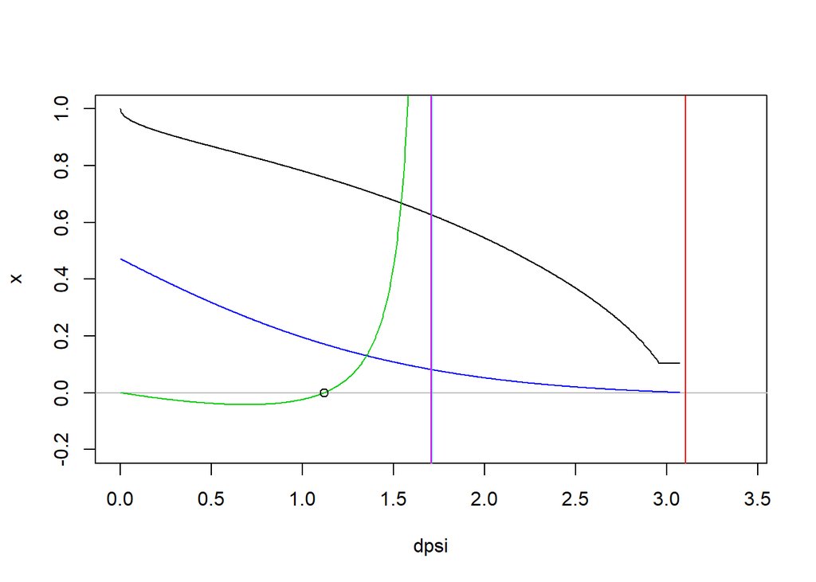

```r
psi_soil = -2
tc = 24.591837
ppfd = 300
vpd = 1000
co2 = 400
elv = 0
fapar = 0.7
kphio = 0.087
rdark = 0

p = rpmodel::calc_patm(elv)

par_photosynth_test <- list(
  kmm = rpmodel::calc_kmm(tc, p),  # Why does this use std. atm pressure, and not p(z)?
  gammastar = rpmodel::calc_gammastar(tc, p),
  phi0 = kphio*rpmodel::calc_ftemp_kphio(tc),
  Iabs = ppfd*fapar,
  ca = co2*p*1e-6,  # Convert to partial pressure
  patm = p,
  delta = rdark
)

par_env_test = list(
  viscosity_water = rpmodel::calc_viscosity_h2o(tc, p),  # Needs to be imported from rpmodel.R
  density_water = rpmodel::calc_density_h2o(tc, p),  # Needs to be imported from rpmodel.R
  patm = p,
  tc = tc,
  vpd = vpd
)

par_cost_test = list(alpha=0.1, gamma=.1)

par_plant_test = par_plant_proto_pm

# par_env_test=par_env_std
# par_plant_test=par_plant_std

dpsi_max = calc_dpsi_bound(psi_soil, par_plant = par_plant_test, par_env = par_env_test, par_photosynth = par_photosynth_test, par_cost = par_cost_test)

dpsi = seq(0,dpsi_max$exact*0.99, length.out=1000)

x = calc_x_from_dpsi(dpsi, psi_soil, par_plant = par_plant_test, par_env = par_env_test, par_photosynth = par_photosynth_test, par_cost = par_cost_test)

delt = calc_delta_from_dpsi(dpsi, psi_soil, par_plant = par_plant_test, par_env = par_env_test, par_photosynth = par_photosynth_test, par_cost = par_cost_test)

dPdx = transpose(lapply(X=dpsi, FUN=dFdx, psi_soil=psi_soil, par_plant = par_plant_test, par_env = par_env_test, par_photosynth = par_photosynth_test, par_cost = par_cost_test))

dpsi_opt = uniroot(f = function(dpsi){dFdx(dpsi, psi_soil = psi_soil, par_plant = par_plant_test, par_env = par_env_test, par_photosynth = par_photosynth_test, par_cost = par_cost_test)$dP_dx}, interval = c(dpsi_max$Iabs_bound*0.0001, dpsi_max$Iabs_bound*0.999))$root

plot(x~dpsi, type="l", ylim=c(-0.2,1), xlim=c(0,max(unlist(dpsi_max), na.rm=T)*1.1))
abline(h=0, col="grey")
points(y=delt/60, x=dpsi, type="l", col="blue")
points(y=unlist(dPdx$dP_dx)/100, x=dpsi, type="l", col="green3")
abline(v=dpsi_max, col=c("red", "cyan3", "magenta"))
points(0~dpsi_opt)
```

```r
#plot(unlist(dPdx$djmax_dajmax)~dpsi, type="l", ylim=c(0,100))
#points(unlist(dPdx$ajmax)~dpsi, type="l", col="red")
```

## Numerical Solution

### The profit function

Lets see the behaviour of the profit function. Does it have a maximum? How about the LC criterion?

```r
#### Numerical Solver ####


# Calculate coordinated Vcmax (umol/m2/s), given
# - Aj (umol/m2/s)
# - ci, converted to partial pressure (Pa)
# - photosynthesis parameters (K and gamma_star), converted to partial pressures (Pa)
# - b_rd, which is part of photosynthesis parameters
calc_vcmax_coordinated_numerical = function(aj, ci, par_photosynth){
  d = par_photosynth$delta
  vcmax_coord = aj*(ci + par_photosynth$kmm)/(ci*(1-d)- (par_photosynth$gammastar+par_photosynth$kmm*d))
  return(vcmax_coord)
}



# Calculate the net assimilation, i.e. assimilation - costs (umol/m2/s), given
# - par = c(jmax, dpsi), the optimization parameters
# - soil water potential (Mpa)
# - cost parameters (a, a1, b, c, d)
# - photosynthesis parameters
# - Plant parameters
# - Env parameters
# - Optimization hypothesis used (PM or LC)
fn_profit <- function(par, psi_soil, par_cost, par_photosynth, par_plant, par_env, do_optim = FALSE, opt_hypothesis){

  jmax = exp(par[1])  # Jmax in umol/m2/s (logjmax is supplied by the optimizer)
  dpsi = par[2]       # delta Psi in MPa

  gs = calc_gs(dpsi, psi_soil, par_plant, par_env)  # gs in mol/m2/s/Mpa
  E = 1.6*gs*(par_env$vpd/par_env$patm)*1e6         # E in umol/m2/s

  ## light-limited assimilation
  a_j <- calc_assim_light_limited(gs, jmax, par_photosynth) # Aj in umol/m2/s
  a = a_j$a
  ci = a_j$ci
  vcmax = calc_vcmax_coordinated_numerical(a,ci, par_photosynth)

  costs = par_cost$alpha * jmax +
    par_cost$gamma * dpsi^2 #((abs((-dpsi)/par_plant$psi50)))^2

  benefit = 1 #(1+1/(par_photosynth$ca/40.53))/2

  dummy_costs = 0*exp(20*(-abs(dpsi/4)-abs(jmax/1))) # ONLY added near (0,0) for numerical stability.

  if (opt_hypothesis == "PM"){
    ## Profit Maximisation
    out <- a*benefit - costs - dummy_costs
  } else if (opt_hypothesis == "LC"){
    ## Least Cost
    out <- -(costs+dummy_costs) / (a+1e-4)
  }

  if (do_optim){
    return(-out)
  } else {
    return(out)
  }
}

optimise_midterm_multi <- function(fn_profit, psi_soil, par_cost, par_photosynth, par_plant, par_env, return_all = FALSE, opt_hypothesis){

  out_optim <- optimr::optimr(
    par       = c(logjmax=0, dpsi=1),
    lower     = c(-10, .0001),
    upper     = c(10, 1e6),
    fn        = fn_profit,
    psi_soil  = psi_soil,
    par_cost  = par_cost,
    par_photosynth = par_photosynth,
    par_plant = par_plant,
    par_env   = par_env,
    do_optim  = TRUE,
    opt_hypothesis = opt_hypothesis,
    method    = "L-BFGS-B",
    control   = list( maxit = 500, maximize = TRUE, fnscale=1e4 )
  )

  out_optim$value <- -out_optim$value

  if (return_all){
    out_optim
  } else {
    return(out_optim$par)
  }
}
```

```r
pmodel_hydraulics_numerical <- function(tc, ppfd, vpd, co2, elv, fapar, kphio, psi_soil, rdark = 0, par_plant, par_cost = NULL, opt_hypothesis = "PM"){

  p = rpmodel::calc_patm(elv)

  par_photosynth_now <- list(
    kmm = rpmodel::calc_kmm(tc, p),  # Why does this use std. atm pressure, and not p(z)?
    gammastar = rpmodel::calc_gammastar(tc, p),
    phi0 = kphio*rpmodel::calc_ftemp_kphio(tc),
    Iabs = ppfd*fapar,
    ca = co2*p*1e-6,  # Convert to partial pressure
    patm = p,
    delta = rdark
  )

  par_env_now = list(
    viscosity_water = rpmodel::calc_viscosity_h2o(tc, p),  # Needs to be imported from rpmodel.R
    density_water = rpmodel::calc_density_h2o(tc, p),  # Needs to be imported from rpmodel.R
    patm = p,
    tc = tc,
    vpd = vpd
  )

  par_plant_now = par_plant

  if (!is.null(par_cost)){
    par_cost_now = par_cost
  }
  else{
    if (opt_hypothesis == "PM"){
      par_cost_now = list(
        alpha = 0.1,       # cost of Jmax
        gamma = 1          # cost of hydraulic repair
      )
    } else if (opt_hypothesis == "LC"){
      par_cost_now = list(
        alpha = .1,        # cost of Jmax
        gamma = 0.5          # cost of hydraulic repair
      )
    }
  }

  lj_dps = optimise_midterm_multi(fn_profit, psi_soil = psi_soil, par_cost  = par_cost_now, par_photosynth = par_photosynth_now, par_plant = par_plant_now, par_env = par_env_now, opt_hypothesis = opt_hypothesis)

  profit = fn_profit(par = lj_dps, psi_soil = psi_soil, par_cost  = par_cost_now, par_photosynth = par_photosynth_now, par_plant = par_plant_now, par_env = par_env_now, opt_hypothesis = opt_hypothesis)

  jmax = exp(lj_dps[1])
  dpsi = lj_dps[2]

  gs = calc_gs(dpsi=dpsi, psi_soil=psi_soil, par_plant = par_plant_now, par_env = par_env_now)

  a_j = calc_assim_light_limited(gs = gs, jmax = jmax, par_photosynth = par_photosynth_now)
  a = a_j$a
  ci = a_j$ci

  vcmax = calc_vcmax_coordinated_numerical(a,ci, par_photosynth_now)

  return(list(
    jmax=jmax,
    dpsi=dpsi,
    gs=gs,
    a=a,
    ci=ci,
    chi = ci/par_photosynth_now$ca,
    vcmax=vcmax,
    profit = profit,
    chi_jmax_lim = 0
  ))


}
```

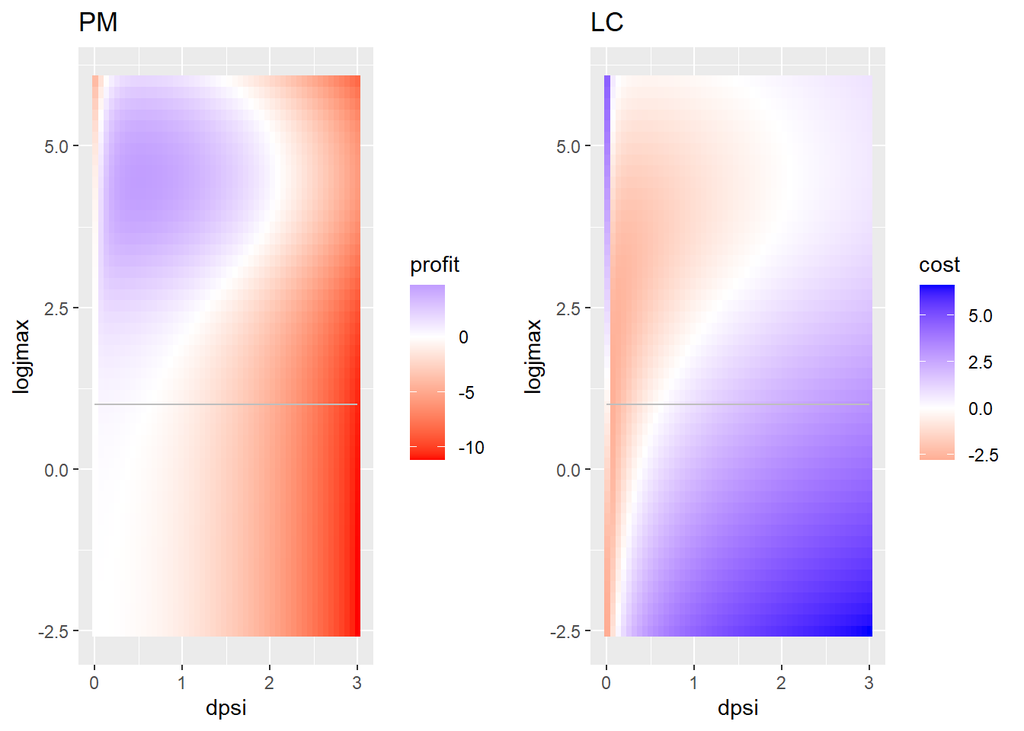

```r
dat <- tibble(dpsi=seq(0.001,3, length.out=50), logjmax = seq(-2.5,6, length.out=50)) %>%  purrr::cross_df() %>%
  mutate(profit = map2(logjmax, dpsi, ~fn_profit(c(.x, .y), psi_soil=0, par_cost = list(alpha=0.01, gamma=5/4), get_std_photosythnesis_params(), par_plant_std, par_env_std, do_optim = FALSE, opt_hypothesis="PM"))) %>% unnest(cols = profit)

p1 = dat %>%
  ggplot(aes(dpsi, logjmax)) +
  geom_raster(aes(fill=profit))+
  scale_fill_gradient2(low="red", high="blue")+
  geom_line(aes(dpsi, 1), col="grey")+
  ggtitle("PM")

dat1 <- tibble(dpsi=seq(0.001,3, length.out=50), logjmax = seq(-2.5,6, length.out=50)) %>%  purrr::cross_df() %>%
  mutate(profit = map2(logjmax, dpsi, ~fn_profit(c(.x, .y), psi_soil=0, par_cost = list(alpha=0.01, gamma=5/4), get_std_photosythnesis_params(), par_plant_std, par_env_std, do_optim = FALSE, opt_hypothesis="LC"))) %>% unnest(cols = profit)

p2 = dat1 %>%
  ggplot(aes(dpsi, logjmax)) +
  geom_raster(aes(fill=log(1e-6-profit)))+
  scale_fill_gradient2(low="red", high="blue")+
  labs(fill="cost")+
  geom_line(aes(dpsi, 1), col="grey") +
  ggtitle("LC")

cowplot::plot_grid(p1,p2, ncol=2, align = "hv", rel_heights = 1, rel_widths = 1)
```

Yes with the PM hypothesis and around a very realistic value of $\Delta \Psi \approx 1$; but not with the LC hypothesis - Minimum occurs at 0!

## Some utilities to facilitate comparison with classic pmodel (Wang et al 2017)

We must convert outputs of the classic model into units that the hydraulic pmodel outputs:

```r
# P-model as per Wang et al 2017
# This needs PPFD in mol/m2/day

pmodel_wang17 = function(tc, ppfd, vpd, co2, elv, fapar, kphio, ...){

    out_analytical <- rpmodel::rpmodel(
          tc             = tc,
          vpd            = vpd,
          co2            = co2,
          elv            = elv,
          kphio          = kphio,
          beta           = 146,
          fapar          = fapar,
          ppfd           = ppfd*1e-6*86400, # p-model requires in mol/m2/day
          ...
          )

  # Convert some outputs to facilitate comparison
  return(list_modify(out_analytical,
                       gs = out_analytical$gs/86400*rpmodel::calc_patm(elv), # mol/m2/day/Pa --> mol/m2/s
                       gpp = out_analytical$gpp/1.03772448,  # gC/m2/day --> umol/m2/s
                       vcmax = out_analytical$vcmax/0.0864,   # mol/m2/day --> umol/m2/s
                       jmax = out_analytical$jmax/0.0864   # mol/m2/day --> umol/m2/s
                      )
  )
}
```

```r
# Combine Hydraulic and classic results

pmodel_calibrate <- function(tc, ppfd, vpd, co2, elv, fapar, kphio, psi_soil, rdark = 0, par_plant, par_cost = NULL, opt_hypothesis = "PM"){
  out_hydraulics = pmodel_hydraulics_analytical(tc, ppfd, vpd, co2, elv, fapar, kphio, psi_soil, rdark, par_plant, par_cost)

  out_analytical = pmodel_wang17(tc, ppfd, vpd, co2, elv, fapar, kphio)

      return(list(out_hydraulics = out_hydraulics,
                  out_analytical = out_analytical))
}

pmodel_calibrate_numerical <- function(tc, ppfd, vpd, co2, elv, fapar, kphio, psi_soil, rdark = 0, par_plant, par_cost = NULL, opt_hypothesis = "PM"){
  out_hydraulics = pmodel_hydraulics_numerical(tc, ppfd, vpd, co2, elv, fapar, kphio, psi_soil, rdark, par_plant, par_cost)

  out_analytical = pmodel_wang17(tc, ppfd, vpd, co2, elv, fapar, kphio)

      return(list(out_hydraulics = out_hydraulics,
                  out_analytical = out_analytical))
}
```

## Soil moisture response

### Acclimated response

Here is a comparison of the hydraulic P-model (line - analytical, points - numerical) with the classic P-model (grey):

```r
l = list()

dat_soilm = tibble(var=seq(-6,0,length.out=50)) %>%
  mutate(out = purrr::map(var, ~pmodel_calibrate(tc = 25, ppfd = 300, vpd = 1000, co2 = 400, elv = 0, fapar = 0.7, kphio = 0.087, psi_soil = ., rdark = 0.02, par_plant = par_plant_proto_pm, par_cost = list(alpha=0.1, gamma=.1))) ) %>%
  unnest_wider(out) %>%
  unnest_wider(out_hydraulics, names_sep = "_") %>%
  unnest_wider(out_analytical, names_sep = "_")
```

[output not shown]

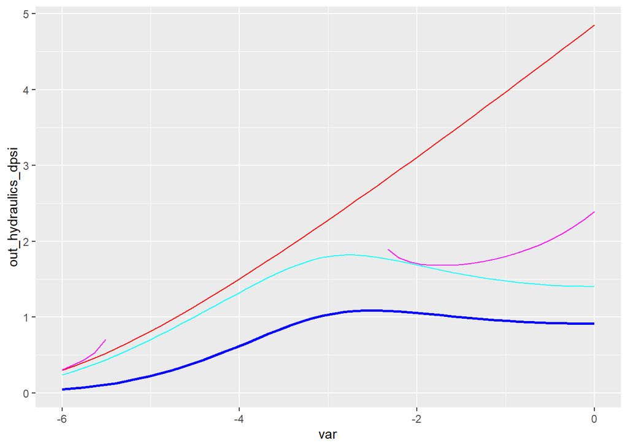

```r
dat_soilm %>%
  ggplot(aes(x=var))+
  geom_line(aes(y=out_hydraulics_dpsi), col="blue", size=1)+
  geom_line(aes(y=out_hydraulics_dpsi_max_exact), col="red")+
  geom_line(aes(y=out_hydraulics_dpsi_max_approx), col="magenta")+
  geom_line(aes(y=out_hydraulics_dpsi_max_Iabs_bound), col="cyan")
```

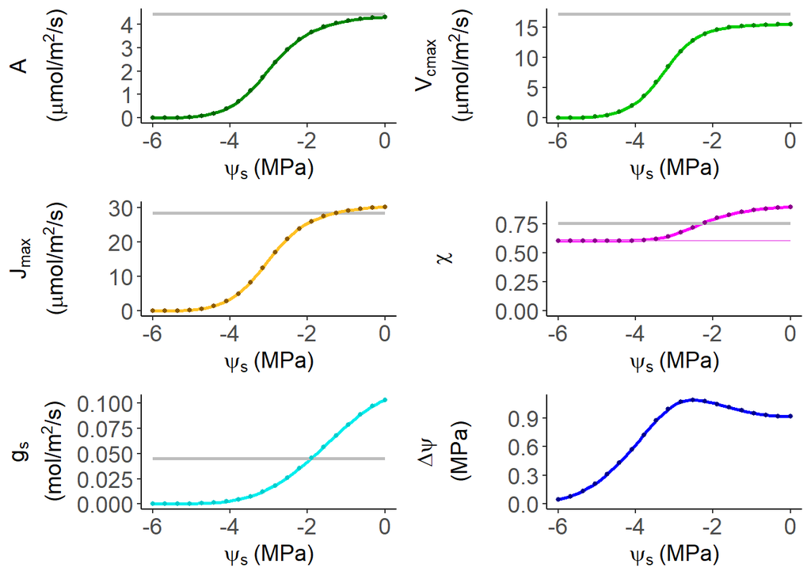

```r
dat_soilm_numerical = tibble(var=seq(-6,0,length.out=20)) %>%
  mutate(out_hydraulics = purrr::map(var, ~pmodel_hydraulics_numerical(tc = 25, ppfd = 300, vpd = 1000, co2 = 400, elv = 0, fapar = 0.7, kphio = 0.087, psi_soil = ., rdark = 0.02, par_plant = par_plant_proto_pm, par_cost = list(alpha=0.1, gamma=.1))) ) %>%
  unnest_wider(out_hydraulics, names_sep = "_")

l1= dat_soilm %>%
  plot_all(expression(psi["s"]~"(MPa)"), ref = dat_soilm_numerical)
l = c(l, l1)

cowplot::plot_grid(plotlist = l1, labels="", label_size = 16, label_colour = "grey50", label_x = 0.3, hjust = 0, align = "hv", rel_widths = 1, nrow=3, byrow=T)
```

### Also compare Approximate and exact versions:

Here is how approximation of gs (points) fares with exact calculation (line).

$$g_s = -\frac{K}{1.6D}\int_{\psi_s}^{\psi_l}{P(\psi)d\psi} \approx \frac{K}{1.6D} P\left(\psi_s -\frac{\Delta \psi}{2}\right)\Delta \psi$$
Therefore,

$$\frac{\partial g_s}{\partial \Delta \psi} \approx \frac{K}{1.6D} \left(P\left(\psi_s -\frac{\Delta \psi}{2}\right) - P'\left(\psi_s -\frac{\Delta \psi}{2}\right)\frac{\Delta \psi}{2}\right)$$

```r
# l = list()

dat_soilm = tibble(var=seq(-6,0,length.out=50)) %>%
  mutate(out = purrr::map(var, ~pmodel_calibrate(tc = 25, ppfd = 300, vpd = 1000, co2 = 400, elv = 0, fapar = 0.7, kphio = 0.087, psi_soil = ., rdark = 0.02, par_plant = par_plant_proto_pm, par_cost = list(alpha=0.1, gamma=.1))) ) %>%
  unnest_wider(out) %>%
  unnest_wider(out_hydraulics, names_sep = "_") %>%
  unnest_wider(out_analytical, names_sep = "_")
```

[output not shown]

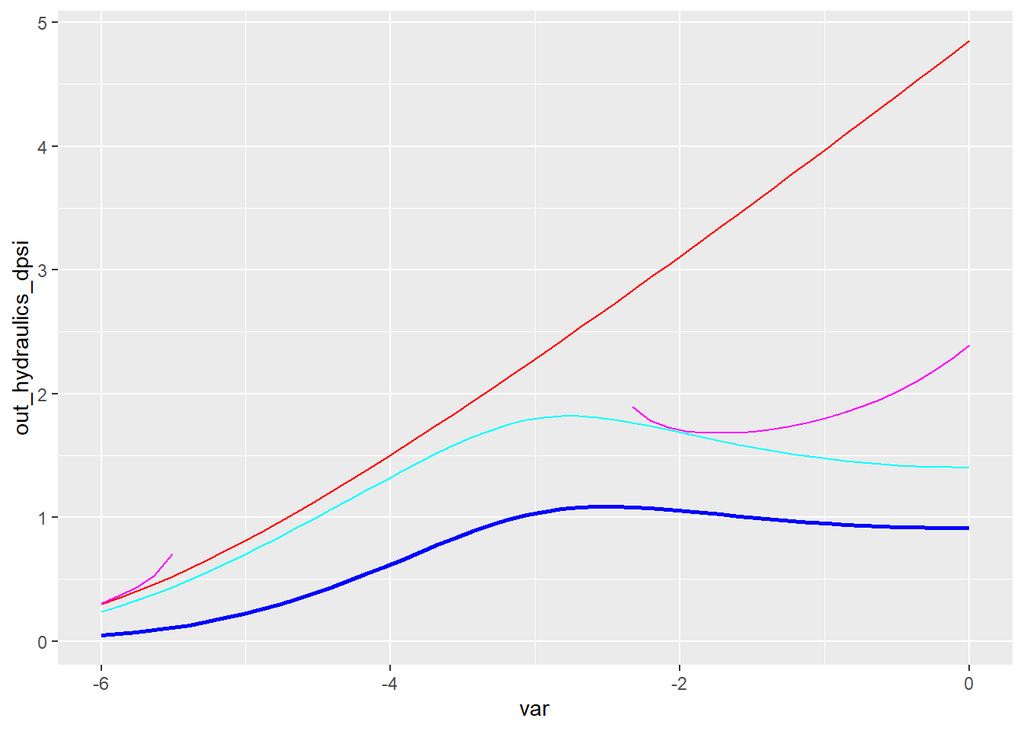

```r
dat_soilm %>%
  ggplot(aes(x=var))+
  geom_line(aes(y=out_hydraulics_dpsi), col="blue", size=1)+
  geom_line(aes(y=out_hydraulics_dpsi_max_exact), col="red")+
  geom_line(aes(y=out_hydraulics_dpsi_max_approx), col="magenta")+
  geom_line(aes(y=out_hydraulics_dpsi_max_Iabs_bound), col="cyan")
```

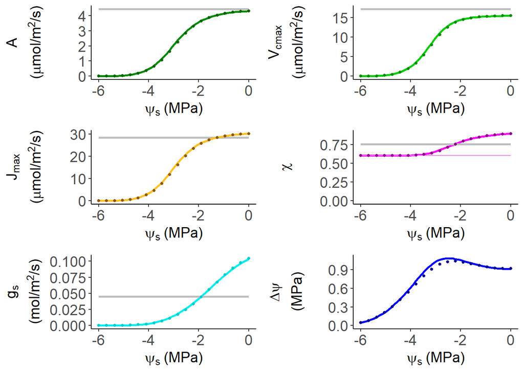

```r
calc_gsprime = calc_gsprime_approx
integral_P = integral_P_approx
dat_soilm_numerical = tibble(var=seq(-6,0,length.out=20)) %>%
  mutate(out_hydraulics = purrr::map(var, ~pmodel_hydraulics_analytical(tc = 25, ppfd = 300, vpd = 1000, co2 = 400, elv = 0, fapar = 0.7, kphio = 0.087, psi_soil = ., rdark = 0.02, par_plant = par_plant_proto_pm, par_cost = list(alpha=0.1, gamma=.1))) ) %>%
  unnest_wider(out_hydraulics, names_sep = "_")
calc_gsprime = calc_gsprime_analytical
integral_P = integral_P_ana

l1= dat_soilm %>%
  plot_all(expression(psi["s"]~"(MPa)"), ref = dat_soilm_numerical)
# l = c(l, l1)

cowplot::plot_grid(plotlist = l1, labels="", label_size = 16, label_colour = "grey50", label_x = 0.3, hjust = 0, align = "hv", rel_widths = 1, nrow=3, byrow=T)
```

### Instantaneous response

If soil dryodown is fast, the plant does not have time to acclimate. In this case, gas-exchange can be calculated for a given (potentially previously acclimated) Vcmax and Jmax, by optimizing only $\Delta \psi$. $g_s$ is calculated using the limiting rate

$$g_s c_a (1-\chi) = \text{min}(A_c, A_j)$$

and profit defined as

$$F = A - \gamma \Delta \psi ^2$$

```r
#### Instantaneous Numerical Solver ####

# Calculate the net assimilation, i.e. assimilation - costs (umol/m2/s), given
# - par = c(jmax, dpsi), the optimization parameters
# - Jmax
# - Vcmax
# - soil water potential (Mpa)
# - cost parameters (a, a1, b, c, d)
# - photosynthesis parameters
# - Plant parameters
# - Env parameters
fn_profit_instantaneous = function(par, jmax, vcmax, psi_soil, par_cost, par_photosynth, par_plant, par_env, do_optim=F){
  dpsi = par
  gs = calc_gs(dpsi, psi_soil, par_plant, par_env)
  A = calc_assimilation_limiting(vcmax, jmax, gs, par_photosynth)$a
  profit = A - par_cost$gamma * dpsi^2

  if (do_optim){
    return(-profit)
  } else {
    return(profit)
  }
}


optimise_shortterm <- function(fn_profit_inst, jmax, vcmax, psi_soil, par_cost, par_photosynth, par_plant, par_env, return_all = FALSE){

  out_optim <- optimr::optimr(
    par       = c(dpsi=1),
    lower     = c(0.001),
    upper     = c(20),
    fn        = fn_profit_inst,
    psi_soil  = psi_soil,
    jmax      = jmax,
    vcmax     = vcmax,
    par_cost  = par_cost,
    par_photosynth = par_photosynth,
    par_plant = par_plant,
    par_env   = par_env,
    do_optim  = TRUE,
    # opt_hypothesis = opt_hypothesis,
    method    = "L-BFGS-B",
    control   = list()
  )

  out_optim$value <- -out_optim$value

  if (return_all){
    out_optim
  } else {
    return(out_optim$par)
  }
}
```

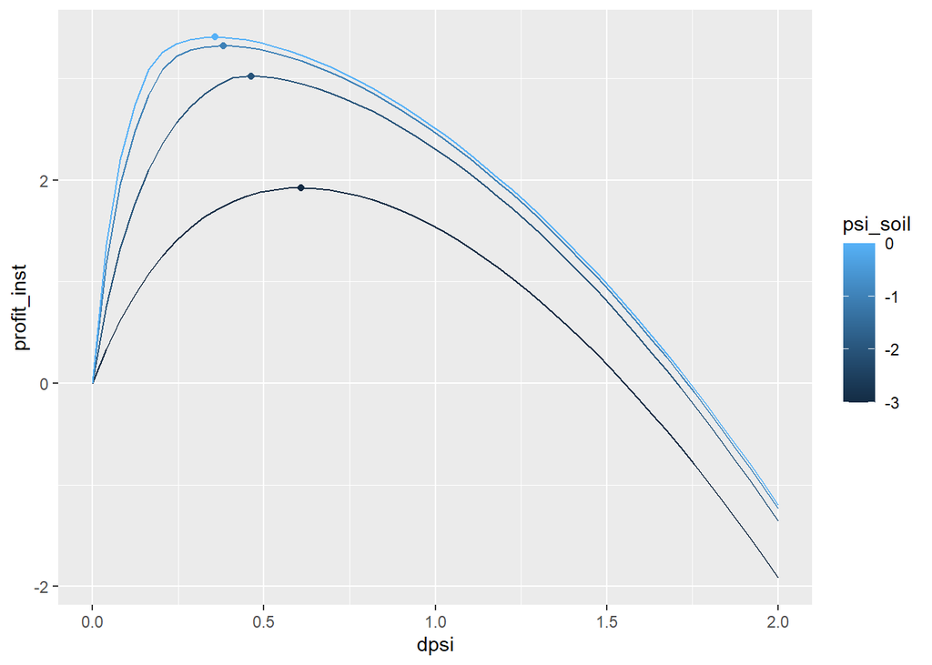

```r
dat <- list(dpsi=seq(0,2, length.out=50), psi_soil = c(0,-1,-2,-3)) %>% cross_df() %>% mutate(profit_inst = map2(dpsi, psi_soil, ~fn_profit_instantaneous(par=.x, jmax=25, vcmax=15, psi_soil=.y, par_cost = list(alpha=0.01, gamma=5/4), par_photosynth = get_std_photosythnesis_params(), par_plant = par_plant_std, par_env = par_env_std))) %>% unnest(cols = profit_inst)


dat_opt <- tibble(psi_soil = c(0,-1,-2,-3)) %>% mutate(dpsi = map(psi_soil, ~optimise_shortterm(fn_profit_inst = fn_profit_instantaneous, jmax=25, vcmax=15, psi_soil=., par_cost = list(alpha=0.01, gamma=5/4), par_photosynth = get_std_photosythnesis_params(), par_plant = par_plant_std, par_env = par_env_std, return_all = T))) %>% unnest_wider(dpsi)

dat %>% ggplot(aes(x=dpsi, y=profit_inst, group=psi_soil, color=psi_soil)) + geom_line() + geom_point(data=dat_opt, mapping = aes(x=par, y=value))
```

```r
pmodel_hydraulics_instantaneous <- function(tc, ppfd, vpd, co2, elv, fapar, kphio, psi_soil, rdark = 0, par_plant, par_cost = NULL, vcmax, jmax, opt_hypothesis = "PM"){

  p = rpmodel::calc_patm(elv)

  par_photosynth_now <- list(
    kmm = rpmodel::calc_kmm(tc, p),  # Why does this use std. atm pressure, and not p(z)?
    gammastar = rpmodel::calc_gammastar(tc, p),
    phi0 = kphio*rpmodel::calc_ftemp_kphio(tc),
    Iabs = ppfd*fapar,
    ca = co2*p*1e-6,  # Convert to partial pressure
    patm = p,
    delta = rdark
  )

  par_env_now = list(
    viscosity_water = rpmodel::calc_viscosity_h2o(tc, p),  # Needs to be imported from rpmodel.R
    density_water = rpmodel::calc_density_h2o(tc, p),  # Needs to be imported from rpmodel.R
    patm = p,
    tc = tc,
    vpd = vpd
  )

  par_plant_now = par_plant

  if (!is.null(par_cost)){
    par_cost_now = par_cost
  }
  else{
    if (opt_hypothesis == "PM"){
      par_cost_now = list(
        alpha = 0.1,       # cost of Jmax
        gamma = 4          # cost of hydraulic repair
      )
    } else if (opt_hypothesis == "LC"){
      par_cost_now = list(
        alpha = .1,        # cost of Jmax
        gamma = 2          # cost of hydraulic repair
      )
    }
  }

  dpsi = optimise_shortterm(fn_profit_instantaneous, jmax=jmax, vcmax=vcmax, psi_soil = psi_soil, par_cost  = par_cost_now, par_photosynth = par_photosynth_now, par_plant = par_plant_now, par_env = par_env_now)

  gs = calc_gs(dpsi, psi_soil, par_plant_now, par_env_now)

  a_l = calc_assimilation_limiting(vcmax, jmax, gs, par_photosynth_now)

  a = a_l$a
  ci = a_l$ci

  profit = a - par_cost_now$gamma*dpsi^2

  return(list(
    jmax=jmax,
    dpsi=dpsi,
    gs=gs,
    a=a,
    ci=ci,
    ac = a_l$ac,
    aj = a_l$aj,
    chi = ci/par_photosynth_now$ca,
    vcmax=vcmax,
    profit = profit,
    chi_jmax_lim = 0
  ))


}
```

```r
pmodel_calibrate_inst <- function(tc, ppfd, vpd, co2, elv, fapar, kphio, psi_soil, rdark = 0, par_plant, par_cost = NULL, jmax, vcmax, opt_hypothesis = "PM"){
  out_hydraulics = pmodel_hydraulics_instantaneous(tc, ppfd, vpd, co2, elv, fapar, kphio, psi_soil, rdark, par_plant, par_cost, vcmax = vcmax, jmax=jmax)

  out_analytical = pmodel_wang17(tc, ppfd, vpd, co2, elv, fapar, kphio)

      return(list(out_hydraulics = out_hydraulics,
                  out_analytical = out_analytical))
}
```

Compare the acclimated (points) and instantaneous (lines) responses.

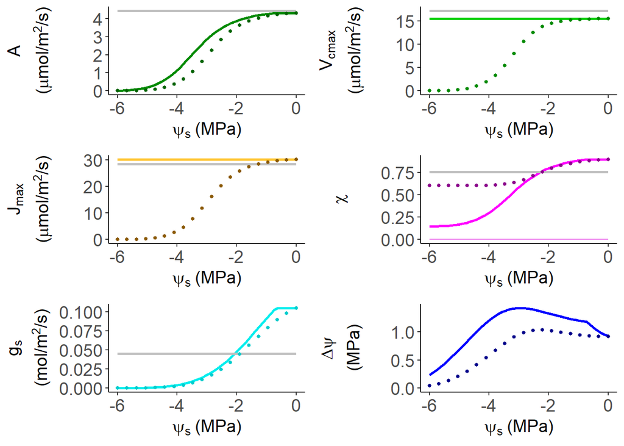

```r
# l = list()

jmax_acc = dat_soilm_numerical$out_hydraulics_jmax[length(dat_soilm_numerical$out_hydraulics_jmax)]
vcmax_acc = dat_soilm_numerical$out_hydraulics_vcmax[length(dat_soilm_numerical$out_hydraulics_vcmax)]
gs_acc = dat_soilm_numerical$out_hydraulics_gs[length(dat_soilm_numerical$out_hydraulics_gs)]

dat_soilm_inst = tibble(var=seq(-6,0,length.out=50)) %>%
  mutate(out = purrr::map(var, ~pmodel_calibrate_inst(tc = 25, ppfd = 300, vpd = 1000, co2 = 400, elv = 0, fapar = 0.7, kphio = 0.087, psi_soil = ., rdark = 0.02, par_plant = par_plant_proto_pm, par_cost = list(alpha=0.1, gamma=0.1), jmax = jmax_acc, vcmax = vcmax_acc)) ) %>%
  unnest_wider(out) %>%
  unnest_wider(out_hydraulics, names_sep = "_") %>%
  unnest_wider(out_analytical, names_sep = "_")



l1= dat_soilm_inst %>%
  plot_all(expression(psi["s"]~"(MPa)"), ref=dat_soilm_numerical)
# l = c(l, l1)

cowplot::plot_grid(plotlist = l1, labels="", label_size = 16, label_colour = "grey50", label_x = 0.3, hjust = 0, align = "hv", rel_widths = 1, nrow=3, byrow=T)
```

```r
# dat = tibble(psi=seq(-6,0,length.out=30)) %>% mutate(Px= 3*P(psi, -2, 1)) %>% mutate(Pox = 30*P(psi, -2, 1.5))
#
# calc_dpsi_X = function(dpsi, psi_soil, par_plant_x, par_plant_ox){
#
#   a = nleqslv::nleqslv(dpsi/2, fn = function(dpsi_x){par_plant_x$conductivity*1e16*integral_P(dpsi = dpsi_x, psi_soil = psi_soil, psi50 = par_plant_x$psi50, b = par_plant_x$b) - par_plant_ox$conductivity*1e16*integral_P(dpsi = dpsi-dpsi_x, psi_soil = psi_soil-dpsi_x, psi50 = par_plant_ox$psi50, b = par_plant_ox$b)})
#   # print(a)
#   a$x
# }
#
# psix = 0 - calc_dpsi_X(1.5, 0, list(conductivity=3, psi50=-2, b=1), list(conductivity=30, psi50=-2, b=1.5))
#
# dat %>% ggplot() +
#   geom_line(aes(x=psi, y=Px), col="brown") +
#   geom_line(aes(x=psi, y=Pox), col="green3") +
#   geom_vline(xintercept = c(psix,-1.5))
#
#
#
# par_plant_x1 =  list(conductivity=0.89e-16, psi50=-1.5, b=1)
# par_plant_ox1 = list(conductivity=5.34e-16, psi50=-1.5, b=1.5)
#
# tibble(dpsi=seq(0,3,by=0.1)) %>% mutate(dpsi_x = purrr::map_dbl(dpsi, ~calc_dpsi_X(., 0, par_plant_x = par_plant_x1, par_plant_ox=par_plant_ox1))) %>%
#   ggplot(aes(x=dpsi, y=dpsi_x)) + geom_line()
#
#
# par_plant_inf = list(conductivity=1e-10, psi50=-50, b=2)
#
# calc_gs_back = calc_gs
#
# calc_gs = function(dpsi, psi_soil, par_plant, par_env, par_plant_x = par_plant_x1, ...){
#
#   par_plant_x =  list(conductivity=0.89e-16, psi50=-1.5, b=1)
#   dpsi_x = calc_dpsi_X(dpsi = dpsi, psi_soil = psi_soil, par_plant_x = par_plant_x, par_plant_ox = par_plant)
#
#   K = scale_conductivity(par_plant$conductivity, par_env)
#   D = (par_env$vpd/par_env$patm)
#   K/1.6/D * -integral_P(dpsi = dpsi-dpsi_x, psi_soil = psi_soil-dpsi_x, psi50 = par_plant$psi50, b = par_plant$b)
# }
#
# tibble(dpsi=seq(0, 3, 0.2)) %>%
#   mutate(gs_old = purrr::map_dbl(dpsi, ~calc_gs_back(., 0, par_plant_x1, par_env_std))) %>%
#   mutate(gs = purrr::map_dbl(dpsi, ~calc_gs(., 0, par_plant_ox1, par_env_std, par_plant_x = par_plant_x1))) %>%
#   ggplot()+
#   geom_line(aes(x=dpsi, y=gs))+
#   geom_point(aes(x=dpsi, y=gs_old))
```

Why is there a difference between the two optimizations?

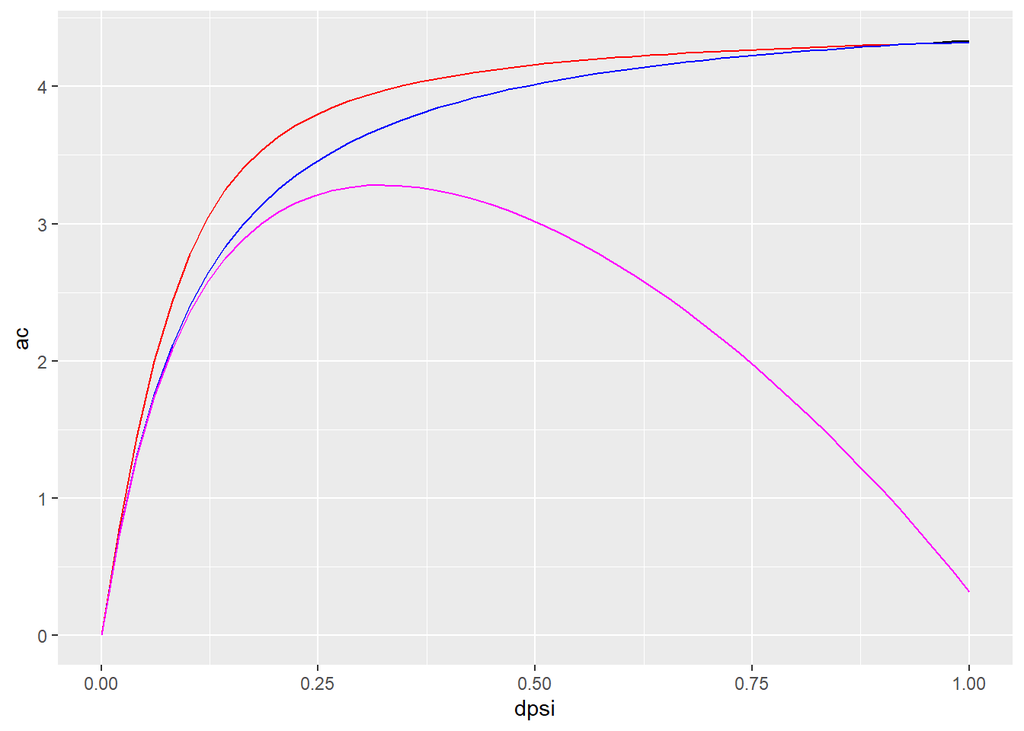

```r
tc = 25
ppfd = 300
vpd = 1000
co2 = 400
elv = 0
fapar = 0.7
kphio = 0.087
psi_soil = 0
rdark = 0.02

p = rpmodel::calc_patm(elv)

par_photosynth_now <- list(
  kmm = rpmodel::calc_kmm(tc, p),  # Why does this use std. atm pressure, and not p(z)?
  gammastar = rpmodel::calc_gammastar(tc, p),
  phi0 = kphio*rpmodel::calc_ftemp_kphio(tc),
  Iabs = ppfd*fapar,
  ca = co2*p*1e-6,  # Convert to partial pressure
  patm = p,
  delta = rdark
)

par_env_now = list(
  viscosity_water = rpmodel::calc_viscosity_h2o(tc, p),  # Needs to be imported from rpmodel.R
  density_water = rpmodel::calc_density_h2o(tc, p),  # Needs to be imported from rpmodel.R
  patm = p,
  tc = tc,
  vpd = vpd
)

par_plant_now = par_plant_proto_pm

par_cost_now = list(
  alpha = 0.1,       # cost of Jmax
  gamma = 4          # cost of hydraulic repair
)

dat9 = tibble(dpsi = seq(0, 1, length.out=50)) %>% mutate(gs = map_dbl(dpsi, ~calc_gs(., psi_soil, par_plant_now, par_env_now))) %>% mutate(ps = map(gs, ~calc_assimilation_limiting(vcmax_acc, jmax_acc, ., par_photosynth = par_photosynth_now))) %>% unnest_wider(ps) %>%
  mutate(Facc = map_dbl(dpsi, ~fn_profit(c(log(jmax_acc), .), psi_soil, par_cost_now, par_photosynth_now, par_plant_now, par_env_now, do_optim = F, "PM"))) %>%
  mutate(Facc_inst = map_dbl(dpsi, ~fn_profit_instantaneous(., jmax_acc, vcmax_acc, psi_soil, par_cost_now, par_photosynth_now, par_plant_now, par_env_now, do_optim = F)))


dat9 %>% ggplot() +
  geom_line(aes(x=dpsi, y=ac))+
  geom_line(aes(x=dpsi, y=aj), col="red")+
  geom_line(aes(x=dpsi, y=a), col="blue")+
  # geom_line(aes(x=dpsi, y=Facc), col="brown")+
  geom_line(aes(x=dpsi, y=Facc_inst), col="magenta")
```

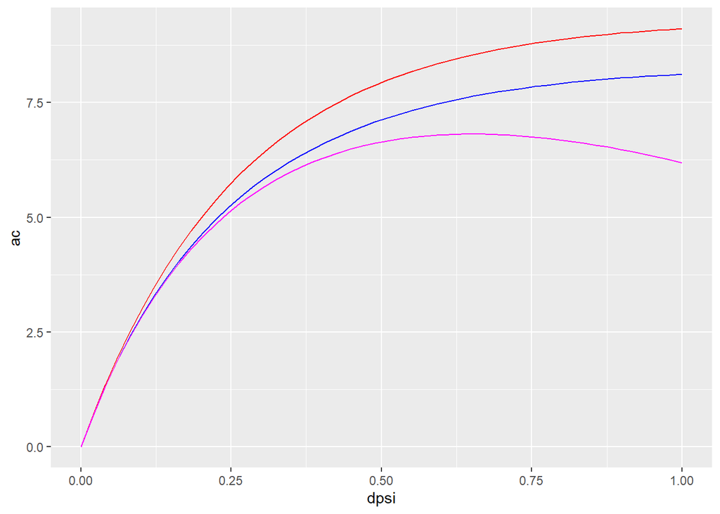

```r
tc = 25
ppfd = 1000
vpd = 0.009924856*1.01325e5
co2 = 380
elv = 0
fapar = 0.99
kphio = 0.087
psi_soil = 0
rdark = 0.02

p = rpmodel::calc_patm(elv)

par_photosynth_now <- list(
  kmm = rpmodel::calc_kmm(tc, p),  # Why does this use std. atm pressure, and not p(z)?
  gammastar = rpmodel::calc_gammastar(tc, p),
  phi0 = kphio*rpmodel::calc_ftemp_kphio(tc),
  Iabs = ppfd*fapar,
  ca = co2*p*1e-6,  # Convert to partial pressure
  patm = p,
  delta = rdark
)

par_env_now = list(
  viscosity_water = rpmodel::calc_viscosity_h2o(tc, p),  # Needs to be imported from rpmodel.R
  density_water = rpmodel::calc_density_h2o(tc, p),  # Needs to be imported from rpmodel.R
  patm = p,
  tc = tc,
  vpd = vpd
)

x = c(1.25403400, -0.62849800,  1.65222600,  0.09726957,  1.92620900)

  par_plant_now = list(
    conductivity= x[1]*1e-16, #.7,
    psi50 = x[2], #-.5,
    b=x[3] #1.2
  )

  par_cost_now = list(
    alpha  = x[4], #0.13,       # cost of Jmax
    gamma = x[5] #.1,         # cost of hydraulic repair
  )

  dat_acc = tibble(var = 0) %>% mutate(pmod = map(var, ~pmodel_hydraulics_numerical(tc = tc, ppfd = ppfd, vpd = vpd, co2 = co2, elv = elv, fapar = fapar, kphio = kphio, psi_soil = psi_soil, rdark = rdark, par_plant=par_plant_now, par_cost = par_cost_now, opt_hypothesis = "PM"))) %>% unnest_wider(pmod)

  jmax_acc = dat_acc$jmax
  vcmax_acc = dat_acc$vcmax

psi_soil = -1

dat9 = tibble(dpsi = seq(0, 1, length.out=50)) %>% mutate(gs = map_dbl(dpsi, ~calc_gs(., psi_soil, par_plant_now, par_env_now))) %>% mutate(ps = map(gs, ~calc_assimilation_limiting(vcmax_acc, jmax_acc, ., par_photosynth = par_photosynth_now))) %>% unnest_wider(ps) %>%
  mutate(Facc = map_dbl(dpsi, ~fn_profit(c(log(jmax_acc), .), psi_soil, par_cost_now, par_photosynth_now, par_plant_now, par_env_now, do_optim = F, "PM"))) %>%
  mutate(Facc_inst = map_dbl(dpsi, ~fn_profit_instantaneous(., jmax_acc, vcmax_acc, psi_soil, par_cost_now, par_photosynth_now, par_plant_now, par_env_now, do_optim = F)))


dat9 %>% ggplot() +
  geom_line(aes(x=dpsi, y=ac))+
  geom_line(aes(x=dpsi, y=aj), col="red")+
  geom_line(aes(x=dpsi, y=a), col="blue")+
  # geom_line(aes(x=dpsi, y=Facc), col="brown")+
  geom_line(aes(x=dpsi, y=Facc_inst), col="magenta")
```

### Temperature response

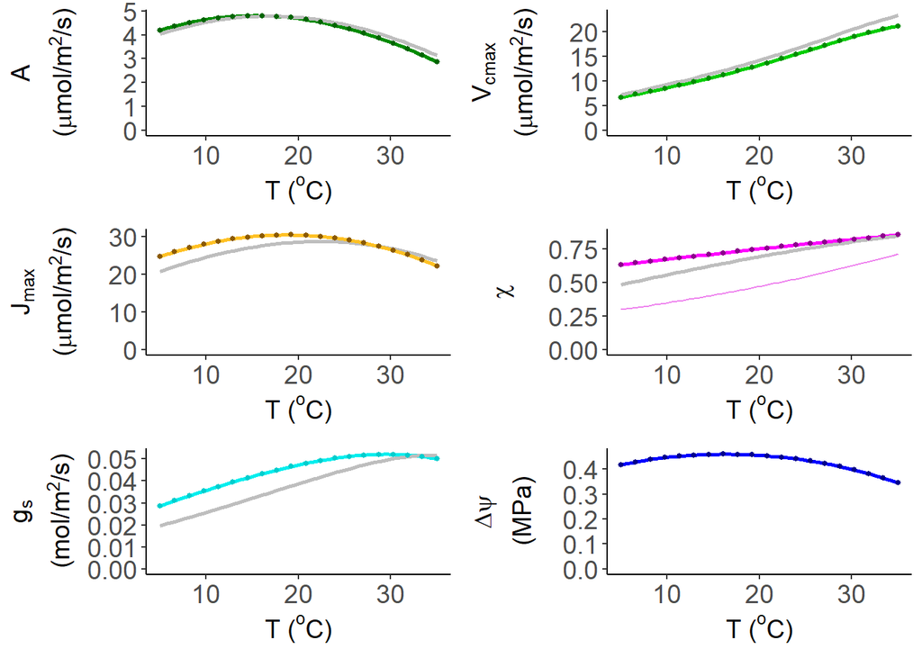

```r
dat = tibble(var=seq(5,35,length.out=50)) %>%
  mutate(out = purrr::map(var, ~pmodel_calibrate(tc = ., ppfd = 300, vpd = 1000, co2 = 400, elv = 0, fapar = 0.7, kphio = 0.087, psi_soil = 0, rdark = 0, par_plant_proto_pm)) ) %>%
  unnest_wider(out) %>%
  unnest_wider(out_hydraulics, names_sep = "_") %>%
  unnest_wider(out_analytical, names_sep = "_")

dat_num = tibble(var=seq(5,35,length.out=20)) %>%
  mutate(out = purrr::map(var, ~pmodel_calibrate_numerical(tc = ., ppfd = 300, vpd = 1000, co2 = 400, elv = 0, fapar = 0.7, kphio = 0.087, psi_soil = 0, rdark = 0, par_plant_proto_pm)) ) %>%
  unnest_wider(out) %>%
  unnest_wider(out_hydraulics, names_sep = "_") %>%
  unnest_wider(out_analytical, names_sep = "_")



calc_gsprime = calc_gsprime_approx
integral_P = integral_P_approx
dat_approx = tibble(var=seq(5,35,length.out=20)) %>%
  mutate(out_hydraulics = purrr::map(var, ~pmodel_hydraulics_analytical(tc = ., ppfd = 300, vpd = 1000, co2 = 400, elv = 0, fapar = 0.7, kphio = 0.087, psi_soil = 0, rdark = 0, par_plant_proto_pm, par_cost=NULL)) ) %>%
  unnest_wider(out_hydraulics, names_sep = "_")
calc_gsprime = calc_gsprime_analytical
integral_P = integral_P_ana

d = dat %>% plot_all(expression("T ("^"o"*"C)"), ref=dat_num)


l = c(l,d)
cowplot::plot_grid(plotlist = d, labels="", label_size = 16, label_colour = "grey50", label_x = 0.3, hjust = 0, align = "hv", rel_widths = 1, nrow=3, byrow=T)
```

### VPD response

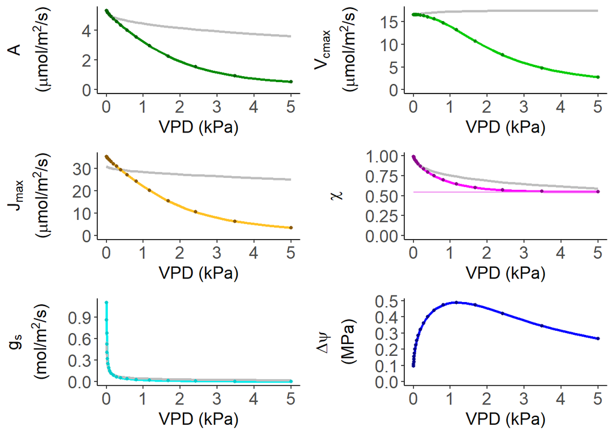

```r
dat = tibble(var=exp(seq(log(5),log(5000),length.out=50))/1000) %>%
  mutate(out = purrr::map(var, ~pmodel_calibrate(tc = 25, ppfd = 300, vpd = .*1000, co2 = 400, elv = 0, fapar = 0.7, kphio = 0.087, psi_soil = -2, rdark = 0, par_plant = par_plant_proto_pm )) ) %>%
  unnest_wider(out) %>%
  unnest_wider(out_hydraulics, names_sep = "_") %>%
  unnest_wider(out_analytical, names_sep = "_")

dat_num = tibble(var=exp(seq(log(5),log(5000),length.out=20))/1000) %>%
  mutate(out = purrr::map(var, ~pmodel_calibrate_numerical(tc = 25, ppfd = 300, vpd = .*1000, co2 = 400, elv = 0, fapar = 0.7, kphio = 0.087, psi_soil = -2, rdark = 0, par_plant = par_plant_proto_pm )) ) %>%
  unnest_wider(out) %>%
  unnest_wider(out_hydraulics, names_sep = "_") %>%
  unnest_wider(out_analytical, names_sep = "_")


# write.table(x = dat %>% select(-out_analytical, -out_hydraulics_profit, -out_hydraulics_chi_jmax_lim), file="~/codes/phydro_cpp/vpd.tsv", sep = "\t", row.names = F, col.names = F)

calc_gsprime = calc_gsprime_approx
integral_P = integral_P_approx
dat_approx = tibble(var=exp(seq(log(5),log(5000),length.out=20))/1000) %>%
  mutate(out_hydraulics = purrr::map(var, ~pmodel_hydraulics_analytical(tc = 25, ppfd = 300, vpd = .*1000, co2 = 400, elv = 0, fapar = 0.7, kphio = 0.087, psi_soil = -2, rdark = 0, par_plant = par_plant_proto_pm, par_cost=NULL )) ) %>%
  unnest_wider(out_hydraulics, names_sep = "_")
calc_gsprime = calc_gsprime_analytical
integral_P = integral_P_ana



l1 = dat %>% plot_all(expression("VPD (kPa)"), ref=dat_num)
l = c(l, l1)
cowplot::plot_grid(plotlist = l1, labels="", label_size = 16, label_colour = "grey50", label_x = 0.3, hjust = 0, align = "hv", rel_widths = 1, nrow=3, byrow=T)
```

### CO2 response

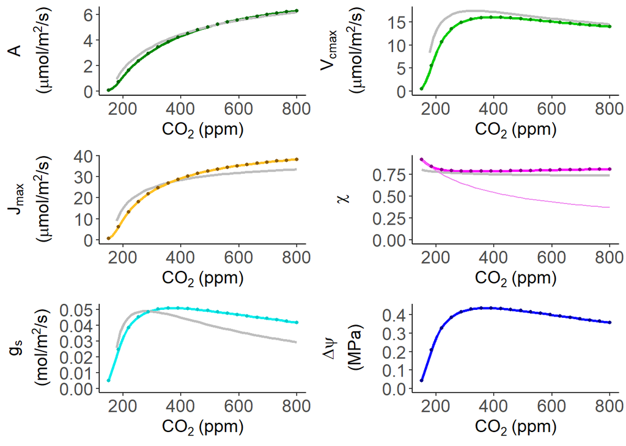

```r
dat = tibble(var=seq(150,800,length.out=50)) %>%
  mutate(out = purrr::map(var, ~pmodel_calibrate(tc = 25, ppfd = 300, vpd = 1000, co2 = ., elv = 0, fapar = 0.7, kphio = 0.087, psi_soil = 0, rdark = 0, par_plant_proto_pm)) ) %>%
  unnest_wider(out) %>%
  unnest_wider(out_hydraulics, names_sep = "_") %>%
  unnest_wider(out_analytical, names_sep = "_")

dat_num = tibble(var=seq(150,800,length.out=20)) %>%
  mutate(out = purrr::map(var, ~pmodel_calibrate_numerical(tc = 25, ppfd = 300, vpd = 1000, co2 = ., elv = 0, fapar = 0.7, kphio = 0.087, psi_soil = 0, rdark = 0, par_plant_proto_pm)) ) %>%
  unnest_wider(out) %>%
  unnest_wider(out_hydraulics, names_sep = "_") %>%
  unnest_wider(out_analytical, names_sep = "_")
# write.table(x = dat %>% select(-out_analytical, -out_hydraulics_profit, -out_hydraulics_chi_jmax_lim), file="~/codes/phydro_cpp/co2.tsv", sep = "\t", row.names = F, col.names = F)

l1 = dat %>% plot_all(expression("CO"[2]~"(ppm)"), ref=dat_num)
l = c(l, l1)
cowplot::plot_grid(plotlist = l1, labels="", label_size = 16, label_colour = "grey50", label_x = 0.3, hjust = 0, align = "hv", rel_widths = 1, nrow=3, byrow=T)
```

```r
# plot(y=dat$out_hydraulics_vcmax/dat$out_hydraulics_jmax, x=dat$var, ylab="Vcmax/Jmax", xlab="CO2")
```

### Light response

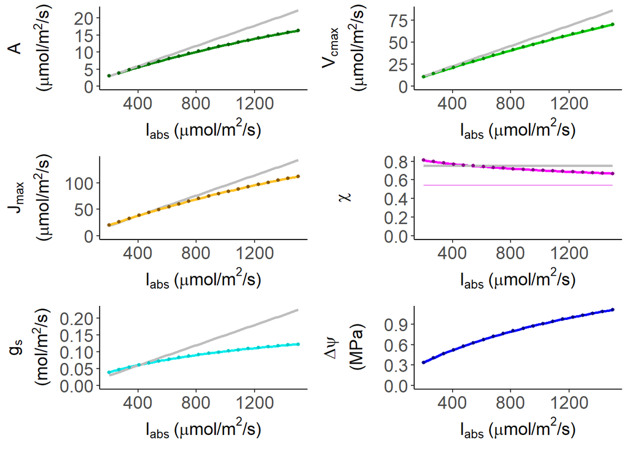

```r
dat = tibble(var=seq(200,1500,length.out=50)) %>%
  mutate(out = purrr::map(var, ~pmodel_calibrate(tc = 25, ppfd = ., vpd = 1000, co2 = 400, elv = 0, fapar = 0.7, kphio = 0.087, psi_soil = 0, rdark = 0, par_plant_proto_pm)) ) %>%
  unnest_wider(out) %>%
  unnest_wider(out_hydraulics, names_sep = "_") %>%
  unnest_wider(out_analytical, names_sep = "_")

dat_num = tibble(var=seq(200,1500,length.out=20)) %>%
  mutate(out = purrr::map(var, ~pmodel_calibrate_numerical(tc = 25, ppfd = ., vpd = 1000, co2 = 400, elv = 0, fapar = 0.7, kphio = 0.087, psi_soil = 0, rdark = 0, par_plant_proto_pm)) ) %>%
  unnest_wider(out) %>%
  unnest_wider(out_hydraulics, names_sep = "_") %>%
  unnest_wider(out_analytical, names_sep = "_")

# write.table(x = dat %>% select(-out_analytical, -out_hydraulics_profit, -out_hydraulics_chi_jmax_lim), file="~/codes/phydro_cpp/ppfd.tsv", sep = "\t", row.names = F, col.names = F)

l1 = dat %>% plot_all(expression("I"["abs"]~"("*mu*"mol/m"^2*"/s)"), ref=dat_num)
l = c(l, l1)
cowplot::plot_grid(plotlist = l1, labels="", label_size = 16, label_colour = "grey50", label_x = 0.3, hjust = 0, align = "hv", rel_widths = 1, nrow=3, byrow=T)
```

```r
# nsets = length(l)/6
#
# png(paste0("C:/Users/Jaideep/OneDrive - IIASA/Phydro_paper/resp_to_vars.png"), height = 1200*3, width = 300*nsets*3, res=300)
# cowplot::plot_grid(plotlist = l, labels="", label_size = 16, label_colour = "grey50", label_x = 0.3, hjust = 0, align = "hv", rel_widths = 1, nrow=6, byrow=F)
# dev.off()
```

### Cost response

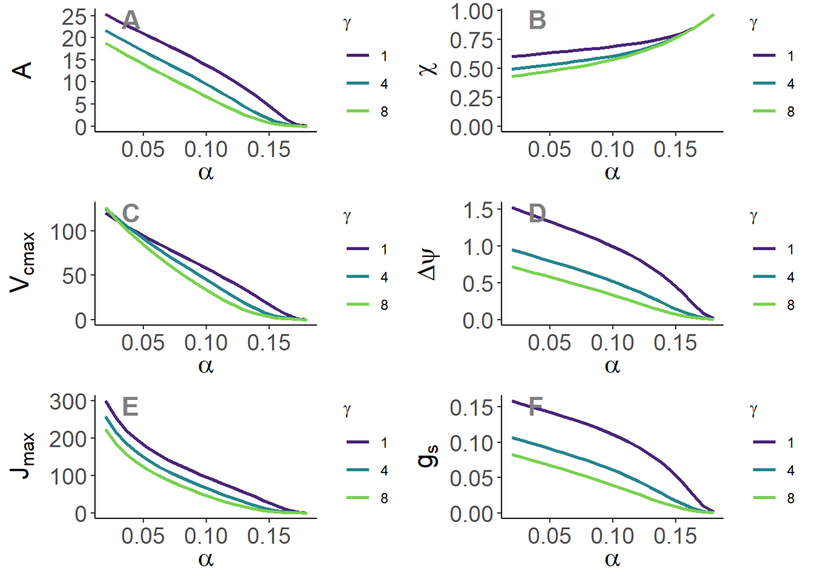

```r
dat = list(alpha=seq(0.02,0.18,length.out=20), gamma = c(1,4,8)) %>% cross_df() %>%
  mutate(out = purrr::map2(alpha, gamma, ~pmodel_calibrate(tc = 25, ppfd = 1200, vpd = 1000, co2 = 400, elv = 0, fapar = 0.7, kphio = 0.087, psi_soil = 0, rdark=0, par_plant_proto_pm, par_cost = list(alpha=.x, gamma=.y))) ) %>%   unnest_wider(out) %>%
  unnest_wider(out_hydraulics, names_sep = "_")

mytheme = function(){
    theme_classic()+
theme(axis.text=element_text(size=14),
      axis.title=element_text(size=16),
      plot.tag.position = "topleft")
}

p1 <- dat %>%
  ggplot() +
  mytheme()+
  geom_line(aes(x = alpha, y = out_hydraulics_vcmax, group=gamma, colour=factor(gamma)), size=1) +
  expand_limits(y=0)+
      scale_color_viridis_d(begin = .1, end=.8)+
    xlab(expression(alpha))+ylab(expression(V["cmax"]))+
  labs(color=expression(gamma))

p2 <- dat %>%
  ggplot() +
  mytheme()+
  geom_line(aes(x = alpha, y = out_hydraulics_dpsi, group=gamma, colour=factor(gamma)), size=1) +
  expand_limits(y=0)+
      scale_color_viridis_d(begin = .1, end=.8)+
    xlab(expression(alpha))+ylab(expression(Delta*psi))+
  labs(color=expression(gamma))


p3 <- dat %>%
  ggplot() +
  mytheme()+
  geom_line(aes(x = alpha, y = out_hydraulics_gs, group=gamma, colour=factor(gamma)), size=1) +
  expand_limits(y=0)+
      scale_color_viridis_d(begin = .1, end=.8)+
    xlab(expression(alpha))+ylab(expression(g[s]))+
  labs(color=expression(gamma))


p4 <- dat %>%
  ggplot() +
  mytheme()+
  geom_line(aes(x = alpha, y = out_hydraulics_chi, group=gamma, colour=factor(gamma)), size=1) +
  expand_limits(y=0)+
      scale_color_viridis_d(begin = .1, end=.8)+
    xlab(expression(alpha))+ylab(expression(chi))+
  labs(color=expression(gamma))



p5 <- dat %>%
  ggplot() +
  mytheme()+
  geom_line(aes(x = alpha, y = out_hydraulics_jmax, group=gamma, colour=factor(gamma)), size=1) +
  expand_limits(y=0)+
      scale_color_viridis_d(begin = .1, end=.8)+
    xlab(expression(alpha))+ylab(expression(J[max]))+
  labs(color=expression(gamma))



p6 <- dat %>%
  ggplot() +
  mytheme()+
  geom_line(aes(x = alpha, y = out_hydraulics_a, group=gamma, colour=factor(gamma)), size=1) +
  expand_limits(y=0)+
      scale_color_viridis_d(begin = .1, end=.8)+
    xlab(expression(alpha))+ylab("A")+
  labs(color=expression(gamma))


# pdf(file = "cost_response.pdf", width = 6.8, height=6.9)
cowplot::plot_grid(p6,p1,p5,p4,p2,p3, labels="AUTO", label_size = 16, label_colour = "grey50", label_x = 0.3, hjust = 0, align = "hv", rel_widths = 1, nrow=3, byrow=F)
```

```r
# dev.off()
```

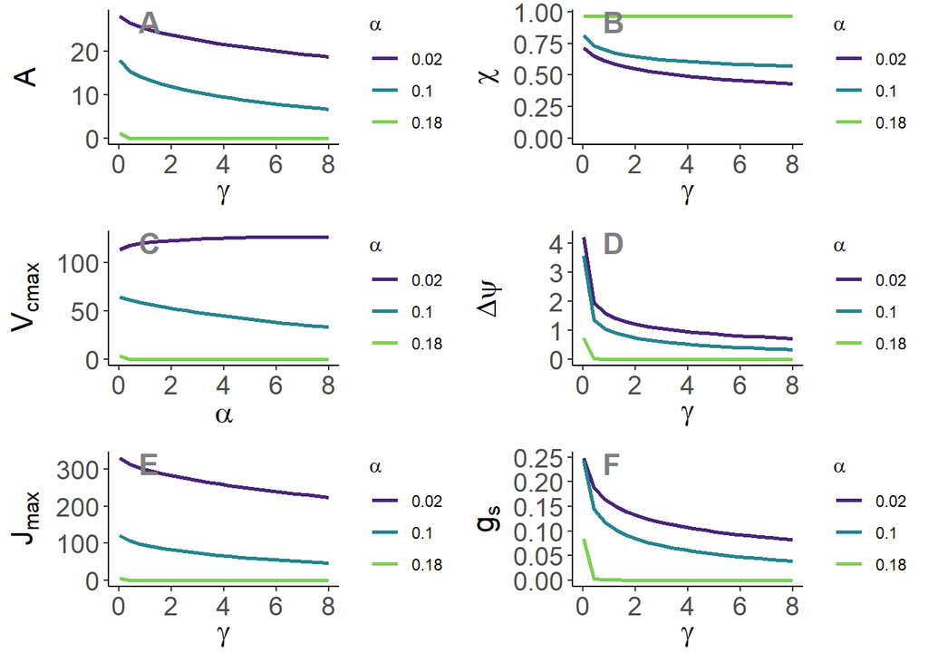

```r
dat = list(alpha=c(0.02, 0.1, 0.18), gamma = seq(0.01,8,length.out=20)) %>% cross_df() %>%
  mutate(out = purrr::map2(alpha, gamma, ~pmodel_calibrate(tc = 25, ppfd = 1200, vpd = 1000, co2 = 400, elv = 0, fapar = 0.7, kphio = 0.087, psi_soil = 0, rdark=0, par_plant_proto_pm, par_cost = list(alpha=.x, gamma=.y))) ) %>%   unnest_wider(out) %>%
  unnest_wider(out_hydraulics, names_sep = "_")

mytheme = function(){
    theme_classic()+
theme(axis.text=element_text(size=14),
      axis.title=element_text(size=16),
      plot.tag.position = "topleft")
}

p1 <- dat %>%
  ggplot() +
  mytheme()+
  geom_line(aes(x = gamma, y = out_hydraulics_vcmax, group=alpha, colour=factor(alpha)), size=1) +
  expand_limits(y=0)+
      scale_color_viridis_d(begin = .1, end=.8)+
    xlab(expression(alpha))+ylab(expression(V["cmax"]))+
  labs(color=expression(alpha))



p2 <- dat %>%
  ggplot() +
  mytheme()+
  geom_line(aes(x = gamma, y = out_hydraulics_dpsi, group=alpha, colour=factor(alpha)), size=1) +
  expand_limits(y=0)+
  scale_color_viridis_d(begin = .1, end=.8)+
  xlab(expression(gamma))+ylab(expression(Delta*psi))+
  labs(color=expression(alpha))


p3 <- dat %>%
  ggplot() +
  mytheme()+
  geom_line(aes(x = gamma, y = out_hydraulics_gs, group=alpha, colour=factor(alpha)), size=1) +
  expand_limits(y=0)+
  scale_color_viridis_d(begin = .1, end=.8)+
  xlab(expression(gamma))+ylab(expression(g[s]))+
  labs(color=expression(alpha))


p4 <- dat %>%
  ggplot() +
  mytheme()+
  geom_line(aes(x = gamma, y = out_hydraulics_chi, group=alpha, colour=factor(alpha)), size=1) +
  expand_limits(y=0)+
  scale_color_viridis_d(begin = .1, end=.8)+
  xlab(expression(gamma))+ylab(expression(chi))+
  labs(color=expression(alpha))



p5 <- dat %>%
  ggplot() +
  mytheme()+
  geom_line(aes(x = gamma, y = out_hydraulics_jmax, group=alpha, colour=factor(alpha)), size=1) +
  expand_limits(y=0)+
  scale_color_viridis_d(begin = .1, end=.8)+
  xlab(expression(gamma))+ylab(expression(J[max]))+
  labs(color=expression(alpha))



p6 <- dat %>%
  ggplot() +
  mytheme()+
  geom_line(aes(x = gamma, y = out_hydraulics_a, group=alpha, colour=factor(alpha)), size=1) +
  expand_limits(y=0)+
  scale_color_viridis_d(begin = .1, end=.8)+
  xlab(expression(gamma))+ylab("A")+
  labs(color=expression(alpha))


# pdf(file = "cost_response.pdf", width = 6.8, height=6.9)
cowplot::plot_grid(p6,p1,p5,p4,p2,p3, labels="AUTO", label_size = 16, label_colour = "grey50", label_x = 0.3, hjust = 0, align = "hv", rel_widths = 1, nrow=3, byrow=F)
```

```r
# dev.off()
```

```r
dat = list(psi_s = seq(-2,0,length.out=20), b = c(0.5,1.8,8)) %>% cross_df() %>%
  mutate(out = purrr::map2(psi_s, b, ~pmodel_calibrate_numerical(tc = 25, ppfd = 1200, vpd = 1000, co2 = 400, elv = 0, fapar = 0.7, kphio = 0.087, psi_soil = .x, rdark=0, list_modify(par_plant_proto_pm, b=.y), par_cost = list(alpha=.1, gamma=.5))) ) %>%   unnest_wider(out) %>%
  unnest_wider(out_hydraulics, names_sep = "_")
```

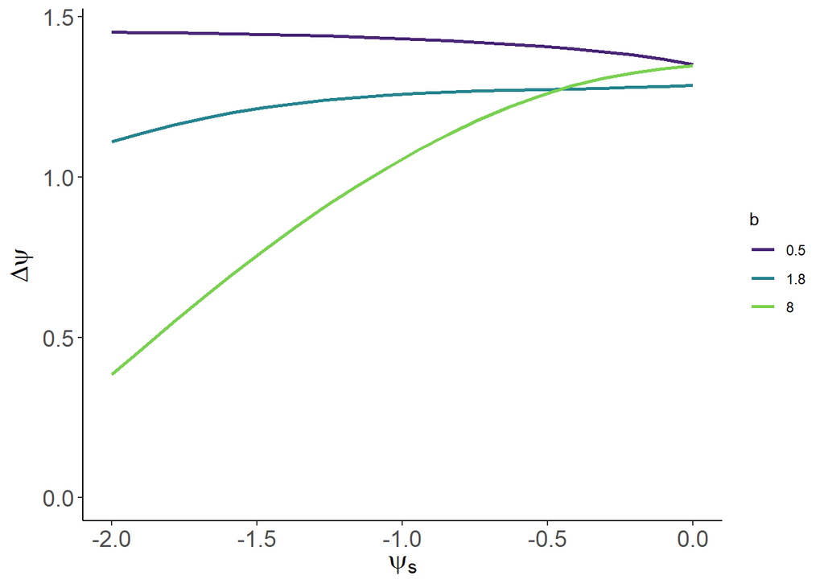

```r
p2 <- dat %>%
  ggplot() +
  mytheme()+
  geom_line(aes(x = psi_s, y = out_hydraulics_dpsi, group=factor(b), colour=factor(b)), size=1) +
  expand_limits(y=0)+
      scale_color_viridis_d(begin = .1, end=.8)+
    xlab(expression(psi[s]))+ylab(expression(Delta*psi))+
  labs(color="b")


p2
```